# Complete Analysis Code for the Empirical Illustration

Xiaohui Luo

2026-08-21

# About this document

This document accompanies the article *Beyond Pre-Post Comparisons: A Comprehensive Effect Size Framework for Intensive Longitudinal Interventions via Time-Varying Modeling* and provides the complete code of all analyses behind its empirical illustration. The document has six sections.

- **Section 1. Setup.** Packages, helper utilities, design constants, MCMC settings, and the shared plotting style.
- **Section 2. The empirical data.** Loading and screening the empirical dataset.
- **Section 3. Analysis functions.** All functions of the analysis, including the two Stan models.
- **Section 4. Analysis of the empirical data.** Model fitting, convergence, and the population-average, individual-specific, and between-group effect sizes for the empirical data.
- **Section 5. Generation of the simulated dataset.** How the simulated dataset analyzed in the tutorial was generated from the empirical posterior.
- **Section 6. Analysis of the simulated dataset.** The identical analysis re-run on the simulated dataset, as demonstrated step by step in the accompanying tutorial.

# 1. Setup

**Packages.**

```r
library(dplyr)     # data wrangling
library(ggplot2)   # figures
library(knitr)     # formatted tables
```

**Helper utilities.**

```r
group_label <- function(group) ifelse(group == 1L, "treatment", "control")
phase_label <- function(phase) ifelse(phase == 1L, "intervention", "baseline")

write_csv <- function(x, path) {
  dir.create(dirname(path), recursive = TRUE, showWarnings = FALSE)
  utils::write.csv(x, path, row.names = FALSE, na = "")
  invisible(path)
}

save_figure <- function(plot, path, width, height, dpi = 320) {
  dir.create(dirname(path), recursive = TRUE, showWarnings = FALSE)
  ggplot2::ggsave(path, plot = plot, width = width, height = height,
                  units = "in", dpi = dpi, bg = "white")
  invisible(path)
}

# Posterior point estimate = median; interval = 95% equal-tailed CrI.
posterior_summary <- function(x) {
  c(q2.5 = stats::quantile(x, 0.025, na.rm = TRUE, names = FALSE),
    median = stats::median(x, na.rm = TRUE),
    q97.5 = stats::quantile(x, 0.975, na.rm = TRUE, names = FALSE))
}

summarise_draw_matrix <- function(draws, time) {
  tibble::tibble(
    time = time,
    q2.5 = apply(draws, 2, stats::quantile, 0.025, na.rm = TRUE),
    median = apply(draws, 2, stats::median, na.rm = TRUE),
    q97.5 = apply(draws, 2, stats::quantile, 0.975, na.rm = TRUE))
}

paper_theme <- function(base_size = 11) {
  ggplot2::theme_minimal(base_size = base_size) +
    ggplot2::theme(
      panel.grid.minor = ggplot2::element_blank(),
      legend.position = "top",
      strip.text = ggplot2::element_text(face = "bold"),
      plot.title.position = "plot",
      plot.title = ggplot2::element_text(face = "bold"))
}

# Panels get an explicit border so plot boundaries and zero lines are clear.
panel_border_theme <- function() {
  ggplot2::theme(panel.border = ggplot2::element_rect(
    color = "grey25", fill = NA, linewidth = 0.6))
}

log_step <- function(...) {
  message(format(Sys.time(), "%H:%M:%S"), " | ", paste0(...))
}
```

**Design constants.**

```r
BEEPS_PER_DAY   <- 6L    # grid slots per day; beeps 5-6 are structural gaps
AUTHENTIC_BEEPS <- 1:4   # beeps at which responses could actually be given
BASELINE_DAYS   <- 8L    # days 1..8   -> baseline phase  (t = 1..48)
TOTAL_DAYS      <- 28L   # days 9..28  -> intervention    (t = 49..168)
BASELINE_T      <- seq_len(BASELINE_DAYS * BEEPS_PER_DAY)          # 1..48
INTERVENTION_T  <- seq.int(max(BASELINE_T) + 1L,
                           TOTAL_DAYS * BEEPS_PER_DAY)             # 49..168
```

**MCMC settings.**

```r
# 2 chains run in parallel with 5000 iterations each; the first 1000 per
# chain are discarded as burn-in, leaving 2 x 4000 = 8000 posterior draws.
# All sampler diagnostics are recorded, but the convergence requirement is
# Rhat < 1.01 for every free parameter.
FORMAL_CONFIG <- list(
  chains = 2L, parallel_chains = 2L,
  iter_warmup = 1000L, iter_sampling = 4000L,
  adapt_delta = 0.99, max_treedepth = 15L,
  refresh = 100L, seed = 20260817L,
  phi_max = 0.95,          # upper bound of |phi| via the tanh link
  k_population = 20L,      # basis size, population-level smooths
  k_individual = 10L,      # basis size, individual-level smooths
  synthetic_n_per_group = 150L,
  rhat_limit = 1.01,
  model_version = "tutorial_single_outcome_v3"
)
```

**Plotting style.**

```r
# Shared plotting style: output folder, panel labels, colors, time axis, theme.
FIG_DIR <- "figures"
dir.create(FIG_DIR, showWarnings = FALSE)
METRICS <- c("mean_standardized", "ar_difference", "local_variance_log_ratio")
panel_labels <- c(
  mean_standardized = "(a) Mean level",
  ar_difference = "(b) Autoregressive coefficient",
  local_variance_log_ratio = "(c) Variance")
CAT_LABELS <- c(neg = "Negative (95% CrI excludes 0)",
                pos = "Positive (95% CrI excludes 0)",
                ns  = "Near zero (95% CrI includes 0)")
CAT_COLORS <- c(neg = "#3498DB", pos = "#E67E22", ns = "gray40")
tp_of <- function(t) t - max(BASELINE_T)          # grid t -> 1..120
TP_BREAKS <- c(1, 30, 60, 90, 120)
X_LAB <- expression("Time point within the intervention phase (" * italic(T)[2] == 120 * ")")

theme_paper <- function(base_size = 10) {
  theme_minimal(base_size = base_size) +
    theme(
      panel.grid.major = element_line(color = "grey78", linetype = "dotted",
                                      linewidth = 0.35),
      panel.grid.minor = element_blank(),
      panel.border = element_rect(color = "grey30", fill = NA,
                                  linewidth = 0.45),
      strip.text = element_text(face = "bold", hjust = 0,
                                size = base_size, color = "black"),
      strip.background = element_blank(),
      axis.text = element_text(color = "black"),
      axis.title = element_text(color = "black"),
      axis.ticks = element_line(color = "black", linewidth = 0.35),
      axis.ticks.length = unit(2.5, "pt"),
      legend.position = "bottom",
      legend.justification = "center",
      plot.background = element_rect(fill = "white", color = NA))
}
```

# 2. The empirical data

The empirical dataset (`empirical_data.csv`) is in long format, with the assessment time points nested within persons. The columns are `id`, `group` (1 = intervention, 0 = control), `day`, `beep`, `t`, `phase`, and `value`, the negative affect score on the 0 to 100 scale.

```r
# Load the empirical dataset and flag the scheduled assessment slots
# (beeps 5 and 6 are the inserted overnight blocks).
empirical_all <- read.csv("empirical_data.csv") |>
  dplyr::mutate(authentic_slot = beep %in% AUTHENTIC_BEEPS)

# Exclude persons whose observed within-person SD is below 0.1 (on the
# 0-100 scale) in at least one phase.
person_sd <- empirical_all |>
  dplyr::filter(authentic_slot, !is.na(value)) |>
  dplyr::group_by(id, phase) |>
  dplyr::summarise(sd = stats::sd(value), .groups = "drop") |>
  dplyr::group_by(id) |>
  dplyr::summarise(min_sd = min(sd), .groups = "drop")
excluded_ids <- person_sd$id[is.na(person_sd$min_sd) |
                               person_sd$min_sd < 0.1]
empirical_data <- dplyr::filter(empirical_all, !id %in% excluded_ids)
excluded_ids
```

```
#> [1]  65  69 113
```

```r
# Descriptive overview per group and phase over the scheduled assessments.
empirical_data |>
  dplyr::filter(authentic_slot) |>
  dplyr::group_by(group, phase) |>
  dplyr::summarise(persons = dplyr::n_distinct(id),
                   observed = sum(!is.na(value)),
                   missing_rate = mean(is.na(value)),
                   observed_mean = mean(value, na.rm = TRUE),
                   observed_sd = stats::sd(value, na.rm = TRUE),
                   .groups = "drop") |>
  dplyr::mutate(group = group_label(group), phase = phase_label(phase)) |>
  kable(digits = 3,
        caption = "Descriptive overview of the empirical data.")
```

Descriptive overview of the empirical data.

| group | phase | persons | observed | missing_rate | observed_mean | observed_sd |
| --- | --- | --- | --- | --- | --- | --- |
| control | baseline | 56 | 1696 | 0.054 | 13.542 | 14.395 |
| control | intervention | 56 | 4238 | 0.054 | 13.749 | 15.383 |
| treatment | baseline | 64 | 1971 | 0.038 | 10.795 | 13.565 |
| treatment | intervention | 64 | 4904 | 0.042 | 9.630 | 13.249 |

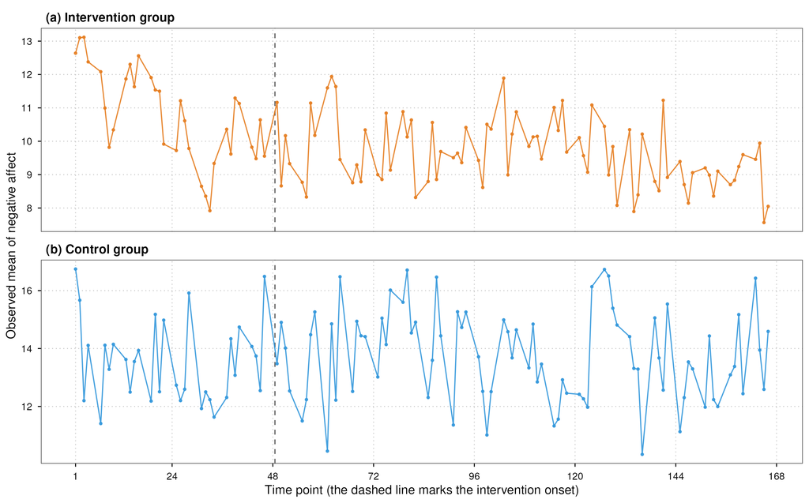

```r
# Observed group means of the empirical data at every scheduled time point,
# one panel per group with its own vertical scale (the dashed line marks
# the intervention onset).
observed_means_emp <- empirical_data |>
  dplyr::filter(authentic_slot, !is.na(value)) |>
  dplyr::group_by(group, t) |>
  dplyr::summarise(mean = mean(value), .groups = "drop") |>
  dplyr::mutate(panel = factor(
    ifelse(group == 1, "(a) Intervention group", "(b) Control group"),
    levels = c("(a) Intervention group", "(b) Control group")))
p_obs_emp <- ggplot(observed_means_emp, aes(t, mean, color = panel)) +
  geom_vline(xintercept = max(BASELINE_T) + 0.5, linetype = "dashed",
             color = "grey40") +
  geom_line(linewidth = 0.45, alpha = 0.9, show.legend = FALSE) +
  geom_point(size = 0.7, alpha = 0.9, show.legend = FALSE) +
  scale_color_manual(values = c("(a) Intervention group" = "#E67E22",
                                "(b) Control group" = "#3498DB")) +
  scale_x_continuous(breaks = c(1, seq(24, 168, 24))) +
  facet_wrap(~panel, ncol = 1, scales = "free_y") +
  labs(x = "Time point (the dashed line marks the intervention onset)",
       y = "Observed mean of negative affect") +
  theme_paper()
dir.create("empirical/figures", recursive = TRUE, showWarnings = FALSE)
ggsave("empirical/figures/observed_means.png", p_obs_emp, width = 9,
       height = 5.6, dpi = 320, bg = "white")
```

# 3. Analysis functions

This section defines all functions of the analysis: the common standardization, the model input matrices, the spline bases, the two Stan models, the model fitting with caching, the convergence diagnostics, the posterior reconstruction, the effect size estimation, and the trajectory figure. The purpose, the arguments, and the return value of each function are documented in its header comment.

```r
# compute_common_scaling(): the shared z-standardization constants.
#   data : long-format data with columns `phase`, `authentic_slot`, `value`
#   Returns list(center, scale), computed from the pooled scheduled baseline
#   observations of both groups.
compute_common_scaling <- function(data) {
  x <- data$value[data$phase == 0L & data$authentic_slot]
  scale <- stats::sd(x, na.rm = TRUE)
  stopifnot("invalid baseline SD" = is.finite(scale) && scale > 0)
  list(center = mean(x, na.rm = TRUE), scale = scale)
}
```

```r
# prepare_phase_matrix(): the persons-by-time input matrix for one model.
#   data    : long-format data frame
#   group   : 0 = control, 1 = intervention
#   phase   : 0 = baseline, 1 = intervention phase
#   scaling : list(center, scale) from compute_common_scaling()
#   Returns a list with the person ids, the grid time points, and the
#   persons-by-time outcome matrix on the z scale (missing cells stay NA).
prepare_phase_matrix <- function(data, group, phase, scaling) {
  rows <- data |>
    dplyr::filter(.data$group == .env$group, .data$phase == .env$phase) |>
    dplyr::arrange(.data$id, .data$t)
  ids <- sort(unique(rows$id))
  times <- sort(unique(rows$t))
  y_raw <- matrix(rows$value, nrow = length(ids), ncol = length(times),
                  byrow = TRUE)
  list(ids = ids, t_global = times,
       y = (y_raw - scaling$center) / scaling$scale,
       scaling = scaling, group = group, phase = phase)
}
```

```r
# prepare_design_matrices(): penalized thin-plate spline bases for the
# multilevel TV-AR model, at two resolutions.
#   Tnum         : number of time points
#   k_population : basis size of the population-level smooths
#   k_individual : basis size of the individual-level smooths
#   Returns, for the intercept (alpha) and the AR coefficient (phi) at both
#   levels, a penalized basis Xr (Tnum x Ks, the wiggly part) and a fixed
#   basis Xf (Tnum x Kf, the linear part).
prepare_design_matrices <- function(Tnum, k_population, k_individual) {
  x <- seq(0, 1, length.out = Tnum)
  make_basis <- function(k, label) {
    # Build one penalized thin-plate spline basis. absorb.cons = TRUE centres
    # the smooth (its fitted values sum to zero over time), so the smooth only
    # captures deviations around the overall level and is not confounded with
    # the intercept. smooth2random() then splits the basis into a fixed
    # (linear) part Xf and a penalized (wiggly) part Xr, whose coefficients
    # act as random effects in Stan.
    smooth <- mgcv::smoothCon(
      mgcv::s(x, k = min(as.integer(k), Tnum - 2L), bs = "tp"),
      data = data.frame(x = x), absorb.cons = TRUE)[[1]]
    random <- mgcv::smooth2random(smooth, label, type = 2)
    list(Xr = unname(as.matrix(random$rand[[1]])),
         Xf = unname(as.matrix(random$Xf)))
  }
  list(alpha = make_basis(k_population, "alpha_pop"),
       phi = make_basis(k_population, "phi_pop"),
       alpha_ind = make_basis(k_individual, "alpha_ind"),
       phi_ind = make_basis(k_individual, "phi_ind"))
}
```

```r
baseline_model_code <- "
// Multilevel time-invariant AR(1) model for the baseline phase.

data {
  int<lower=1> Nnum;                            // number of persons
  int<lower=2> Tnum;                            // number of grid time points
  real<lower=0, upper=1> phi_max;               // upper bound of |phi| (tanh link)
  matrix[Nnum, Tnum] y;                         // observed series (z scale; 0 where missing)
  array[Nnum, Tnum] int<lower=0, upper=1> is_observed;  // 1 = observed, 0 = missing
}

parameters {
  // Population means: gamma[1] = intercept, gamma[2] = raw (unbounded) AR
  // coefficient, gamma[3] = log innovation variance.
  vector[3] gamma;
  matrix[Nnum, 3] u_raw;                        // person random effects, non-centered
  cholesky_factor_corr[3] L_Omega;              // correlation of the random effects
  vector<lower=0>[3] tau;                       // SDs of the random effects
}

model {
  // Person random effects u: scale and correlate the standard-normal u_raw.
  matrix[Nnum, 3] u = diag_post_multiply(u_raw * L_Omega', tau);

  // Weakly informative priors (the outcome is on a common z scale).
  gamma[1] ~ normal(0, 1);
  gamma[2] ~ normal(atanh(0.25 / phi_max), 0.50);
  gamma[3] ~ normal(log(square(0.50)), 1);
  to_vector(u_raw) ~ std_normal();
  L_Omega ~ lkj_corr_cholesky(2);
  tau[1] ~ normal(0, 0.75);
  tau[2] ~ normal(0, 0.35);
  tau[3] ~ normal(0, 0.75);

  // Likelihood, person by person.
  for (i in 1:Nnum) {
    real alpha_i = gamma[1] + u[i, 1];                    // person intercept
    real phi_i = phi_max * tanh(gamma[2] + u[i, 2]);      // person AR coefficient
    real innovation_variance = exp(gamma[3] + u[i, 3]);   // person innovation variance
    real attractor_i = alpha_i / (1 - phi_i);             // person stationary mean
    real stationary_variance = innovation_variance / (1 - square(phi_i));
    int previous_time = 0;                                // last observed time point
    real previous_y = 0;                                  // last observed value

    // Walk through the grid and evaluate only the observed time points.
    // Missing time points (overnight blocks and skipped assessments) are
    // latent: the AR recursion is applied `gap` times between two observed
    // points, which gives the exact Gaussian distribution of the later
    // observation given the earlier one.
    for (t in 1:Tnum) {
      if (is_observed[i, t] == 1) {
        if (previous_time == 0) {
          // First observed point: use the stationary distribution.
          y[i, t] ~ normal(attractor_i, sqrt(stationary_variance));
        } else {
          int gap = t - previous_time;                    // steps since last observation
          real phi_gap = pow(phi_i, gap);                 // AR effect over the gap
          real transition_mean = attractor_i + phi_gap * (previous_y - attractor_i);
          real transition_variance = innovation_variance
            * (1 - pow(phi_i, 2 * gap)) / (1 - square(phi_i));
          y[i, t] ~ normal(transition_mean, sqrt(transition_variance));
        }
        previous_time = t;
        previous_y = y[i, t];
      }
    }
  }
}

generated quantities {
  // Quantities saved for the post-processing in R.
  matrix[Nnum, 3] u = diag_post_multiply(u_raw * L_Omega', tau);
  corr_matrix[3] R_Omega = multiply_lower_tri_self_transpose(L_Omega);
  cov_matrix[3] Sigma_u = quad_form_diag(R_Omega, tau);   // random-effect covariance
}
"
writeLines(baseline_model_code, "ar1_baseline_missing.stan")
```

```r
tvar_model_code <- "
// Multilevel time-varying AR (TV-AR) model for the intervention phase:
// both the intercept and the AR coefficient vary smoothly over time.

data {
  int<lower=1> Nnum;                            // number of persons
  int<lower=2> Tnum;                            // number of grid time points
  real<lower=0, upper=1> phi_max;               // upper bound of |phi| (tanh link)
  matrix[Nnum, Tnum] y;                         // observed series (z scale; 0 where missing)
  array[Nnum, Tnum] int<lower=0, upper=1> is_observed;  // 1 = observed, 0 = missing

  // Population-level spline bases for the time-varying intercept and AR
  // coefficient. Each smooth is split into a penalized (wiggly) part Xr with
  // Ks columns and a fixed (linear) part Xf with Kf columns; see the R
  // function prepare_design_matrices().
  int<lower=1> Ks_alpha;
  matrix[Tnum, Ks_alpha] Xr_alpha;
  int<lower=1> Kf_alpha;
  matrix[Tnum, Kf_alpha] Xf_alpha;
  int<lower=1> Ks_phi;
  matrix[Tnum, Ks_phi] Xr_phi;
  int<lower=1> Kf_phi;
  matrix[Tnum, Kf_phi] Xf_phi;

  // Individual-level spline bases (smaller k), same structure as above.
  int<lower=1> Ks_alpha_ind;
  matrix[Tnum, Ks_alpha_ind] Xr_alpha_ind;
  int<lower=1> Kf_alpha_ind;
  matrix[Tnum, Kf_alpha_ind] Xf_alpha_ind;
  int<lower=1> Ks_phi_ind;
  matrix[Tnum, Ks_phi_ind] Xr_phi_ind;
  int<lower=1> Kf_phi_ind;
  matrix[Tnum, Kf_phi_ind] Xf_phi_ind;
}

parameters {
  // Time-invariant part, as in the baseline model: population means
  // (intercept, raw AR, log innovation variance) and correlated person
  // random effects.
  vector[3] gamma;
  matrix[Nnum, 3] u_raw;
  cholesky_factor_corr[3] L_Omega;
  vector<lower=0>[3] tau;

  // Population-level smooths (non-centered): a_raw_* are the standardized
  // penalized coefficients, tau_s_* their smoothing SD (how wiggly the curve
  // may be), and a0_* the unpenalized linear part.
  real<lower=0> tau_s_alpha;
  vector[Kf_alpha] a0_alpha;
  vector[Ks_alpha] a_raw_alpha;
  real<lower=0> tau_s_phi;
  vector[Kf_phi] a0_phi;
  vector[Ks_phi] a_raw_phi;

  // Individual-level smooth deviations, one row per person: tau_s_*_ind
  // scales the penalized (nonlinear) part and tau_l_*_ind the linear part.
  real<lower=0> tau_s_alpha_ind;
  real<lower=0> tau_l_alpha_ind;
  matrix[Nnum, Kf_alpha_ind] a0_raw_alpha_ind;
  matrix[Nnum, Ks_alpha_ind] a_raw_alpha_ind;
  real<lower=0> tau_s_phi_ind;
  real<lower=0> tau_l_phi_ind;
  matrix[Nnum, Kf_phi_ind] a0_raw_phi_ind;
  matrix[Nnum, Ks_phi_ind] a_raw_phi_ind;
}

model {
  // ---- Assemble the person-by-time parameter surfaces -----------------------
  // Person random effects and scaled spline coefficients.
  matrix[Nnum, 3] u = diag_post_multiply(u_raw * L_Omega', tau);
  vector[Ks_alpha] a_alpha = tau_s_alpha * a_raw_alpha;
  vector[Ks_phi] a_phi = tau_s_phi * a_raw_phi;
  matrix[Nnum, Ks_alpha_ind] a_alpha_ind = tau_s_alpha_ind * a_raw_alpha_ind;
  matrix[Nnum, Kf_alpha_ind] a0_alpha_ind = tau_l_alpha_ind * a0_raw_alpha_ind;
  matrix[Nnum, Ks_phi_ind] a_phi_ind = tau_s_phi_ind * a_raw_phi_ind;
  matrix[Nnum, Kf_phi_ind] a0_phi_ind = tau_l_phi_ind * a0_raw_phi_ind;

  // Population time-varying curves: basis matrix times coefficients.
  row_vector[Tnum] pop_alpha_smooth = (Xr_alpha * a_alpha + Xf_alpha * a0_alpha)';
  row_vector[Tnum] pop_phi_smooth = (Xr_phi * a_phi + Xf_phi * a0_phi)';

  // Person i, time t intercept: population mean + person random effect
  // + population smooth + person smooth deviation. Same structure for phi.
  matrix[Nnum, Tnum] alpha_t = rep_matrix(gamma[1], Nnum, Tnum)
    + rep_matrix(u[, 1], Tnum) + rep_matrix(pop_alpha_smooth, Nnum)
    + a_alpha_ind * Xr_alpha_ind' + a0_alpha_ind * Xf_alpha_ind';
  matrix[Nnum, Tnum] phi_raw_t = rep_matrix(gamma[2], Nnum, Tnum)
    + rep_matrix(u[, 2], Tnum) + rep_matrix(pop_phi_smooth, Nnum)
    + a_phi_ind * Xr_phi_ind' + a0_phi_ind * Xf_phi_ind';
  // Bound the AR coefficient to (-phi_max, phi_max) via the tanh link.
  matrix[Nnum, Tnum] phi_t = phi_max * tanh(phi_raw_t);

  // ---- Priors ---------------------------------------------------------------
  // Weakly informative priors (the outcome is on a common z scale).
  gamma[1] ~ normal(0, 1);
  gamma[2] ~ normal(atanh(0.25 / phi_max), 0.50);
  gamma[3] ~ normal(log(square(0.50)), 1);
  to_vector(u_raw) ~ std_normal();
  L_Omega ~ lkj_corr_cholesky(2);
  tau[1] ~ normal(0, 0.75);
  tau[2] ~ normal(0, 0.35);
  tau[3] ~ normal(0, 0.75);

  // Population smooths.
  a_raw_alpha ~ std_normal();
  a0_alpha ~ normal(0, 0.50);
  tau_s_alpha ~ normal(0, 0.50);
  a_raw_phi ~ std_normal();
  a0_phi ~ normal(0, 0.25);
  tau_s_phi ~ normal(0, 0.25);

  // Individual smooth deviations.
  to_vector(a_raw_alpha_ind) ~ std_normal();
  to_vector(a0_raw_alpha_ind) ~ std_normal();
  tau_s_alpha_ind ~ normal(0, 0.50);
  tau_l_alpha_ind ~ normal(0, 0.50);
  to_vector(a_raw_phi_ind) ~ std_normal();
  to_vector(a0_raw_phi_ind) ~ std_normal();
  tau_s_phi_ind ~ normal(0, 0.20);
  tau_l_phi_ind ~ normal(0, 0.20);

  // ---- Likelihood -----------------------------------------------------------
  // As in the baseline model, only observed time points enter the likelihood.
  // Missing time points are latent: between two observed points the AR
  // recursion is applied step by step (now with time-specific alpha_t and
  // phi_t), accumulating the mean and variance, which gives the exact
  // Gaussian distribution of the later observation given the earlier one.
  for (i in 1:Nnum) {
    real innovation_variance = exp(gamma[3] + u[i, 3]);
    int previous_time = 0;                                // last observed time point
    real previous_y = 0;                                  // last observed value

    for (t in 1:Tnum) {
      if (is_observed[i, t] == 1) {
        real transition_mean;
        real transition_variance;
        if (previous_time == 0) {
          // Before the first observation: start from the local stationary
          // distribution at t = 1 and roll it forward to time t.
          transition_mean = alpha_t[i, 1] / (1 - phi_t[i, 1]);
          transition_variance = innovation_variance / (1 - square(phi_t[i, 1]));
          if (t > 1) {
            for (k in 2:t) {
              transition_mean = alpha_t[i, k] + phi_t[i, k] * transition_mean;
              transition_variance = square(phi_t[i, k]) * transition_variance
                + innovation_variance;
            }
          }
        } else {
          // Roll the AR recursion forward from the last observed value.
          transition_mean = previous_y;
          transition_variance = 0;
          for (k in (previous_time + 1):t) {
            transition_mean = alpha_t[i, k] + phi_t[i, k] * transition_mean;
            transition_variance = square(phi_t[i, k]) * transition_variance
              + innovation_variance;
          }
        }
        y[i, t] ~ normal(transition_mean, sqrt(transition_variance));
        previous_time = t;
        previous_y = y[i, t];
      }
    }
  }
}

generated quantities {
  // Quantities saved for the post-processing in R.
  matrix[Nnum, 3] u = diag_post_multiply(u_raw * L_Omega', tau);
  vector[Ks_alpha] a_alpha = tau_s_alpha * a_raw_alpha;
  vector[Ks_phi] a_phi = tau_s_phi * a_raw_phi;
  matrix[Nnum, Ks_alpha_ind] a_alpha_ind = tau_s_alpha_ind * a_raw_alpha_ind;
  matrix[Nnum, Kf_alpha_ind] a0_alpha_ind = tau_l_alpha_ind * a0_raw_alpha_ind;
  matrix[Nnum, Ks_phi_ind] a_phi_ind = tau_s_phi_ind * a_raw_phi_ind;
  matrix[Nnum, Kf_phi_ind] a0_phi_ind = tau_l_phi_ind * a0_raw_phi_ind;
  corr_matrix[3] R_Omega = multiply_lower_tri_self_transpose(L_Omega);
  cov_matrix[3] Sigma_u = quad_form_diag(R_Omega, tau);   // random-effect covariance
}
"
writeLines(tvar_model_code, "tvar_intervention_missing.stan")
```

```r
# compile_stan_models(): compile the two Stan programs (cached after the
# first compilation). Returns list(baseline, intervention).
compile_stan_models <- function() {
  list(
    baseline = cmdstanr::cmdstan_model(
      "ar1_baseline_missing.stan",
      force_recompile = FALSE, quiet = TRUE),
    intervention = cmdstanr::cmdstan_model(
      "tvar_intervention_missing.stan",
      force_recompile = FALSE, quiet = TRUE))
}

# make_stan_data(): bundle one phase matrix (and, for the TV-AR model, the
# spline bases) into the data list passed to Stan.
#   phase_matrix : output of prepare_phase_matrix()
#   design       : output of prepare_design_matrices(); NULL for the baseline
#   Missing cells are set to 0 and flagged by the indicator `is_observed`,
#   which tells Stan which time points enter the likelihood.
make_stan_data <- function(phase_matrix, design = NULL) {
  y <- phase_matrix$y
  observed <- !is.na(y)
  y[!observed] <- 0   # placeholder; is_observed marks these cells as missing
  out <- list(Nnum = nrow(y), Tnum = ncol(y),
              phi_max = FORMAL_CONFIG$phi_max, y = unname(y),
              is_observed = unname(matrix(as.integer(observed),
                                          nrow(y), ncol(y))))
  if (!is.null(design)) {
    out <- c(out, list(
      Ks_alpha = ncol(design$alpha$Xr), Xr_alpha = design$alpha$Xr,
      Kf_alpha = ncol(design$alpha$Xf), Xf_alpha = design$alpha$Xf,
      Ks_phi = ncol(design$phi$Xr), Xr_phi = design$phi$Xr,
      Kf_phi = ncol(design$phi$Xf), Xf_phi = design$phi$Xf,
      Ks_alpha_ind = ncol(design$alpha_ind$Xr), Xr_alpha_ind = design$alpha_ind$Xr,
      Kf_alpha_ind = ncol(design$alpha_ind$Xf), Xf_alpha_ind = design$alpha_ind$Xf,
      Ks_phi_ind = ncol(design$phi_ind$Xr), Xr_phi_ind = design$phi_ind$Xr,
      Kf_phi_ind = ncol(design$phi_ind$Xf), Xf_phi_ind = design$phi_ind$Xf))
  }
  out
}
```

```r
# fit_phase_model(): fit one group-by-phase model.
#   phase_matrix : output of prepare_phase_matrix()
#   compiled     : output of compile_stan_models()
#   out_dir      : output folder; the fit is stored under models/<group>_<phase>
#   seed_offset  : added to the base seed so every model has its own seed
#   Returns list(fit, meta, diagnostics). If the model folder already holds a
#   fit produced with the same settings, that fit is loaded from disk instead
#   of being re-sampled.
fit_phase_model <- function(phase_matrix, compiled, out_dir, seed_offset) {
  label <- paste(group_label(phase_matrix$group),
                 phase_label(phase_matrix$phase), sep = "_")
  model_dir <- file.path(out_dir, "models", label)
  csv_dir <- file.path(model_dir, "cmdstan_csv")
  dir.create(csv_dir, recursive = TRUE, showWarnings = FALSE)
  # Settings fingerprint used to decide whether a stored fit can be re-used.
  signature <- paste(unlist(FORMAL_CONFIG[c(
    "model_version", "chains", "iter_warmup", "iter_sampling", "adapt_delta",
    "max_treedepth", "phi_max", "k_population", "k_individual")]),
    collapse = "|")
  fit_path <- file.path(model_dir, "fit_object.rds")
  signature_path <- file.path(model_dir, "settings_signature.txt")

  # The TV-AR model additionally needs the spline bases.
  design <- if (phase_matrix$phase == 1L) {
    prepare_design_matrices(ncol(phase_matrix$y),
                            FORMAL_CONFIG$k_population,
                            FORMAL_CONFIG$k_individual)
  }
  phase_matrix$design <- design
  saveRDS(phase_matrix, file.path(model_dir, "model_metadata.rds"),
          compress = "xz")

  reusable <- file.exists(fit_path) && file.exists(signature_path) &&
    identical(readLines(signature_path, warn = FALSE), signature)
  if (reusable) {
    fit <- readRDS(fit_path)
    reusable <- all(file.exists(fit$output_files()))
  }
  if (!reusable) {
    log_step(label, " | formal MCMC started")
    model <- if (phase_matrix$phase == 0L) compiled$baseline else
      compiled$intervention
    fit <- model$sample(
      data = make_stan_data(phase_matrix, design),
      seed = FORMAL_CONFIG$seed + seed_offset,
      chains = FORMAL_CONFIG$chains,
      parallel_chains = FORMAL_CONFIG$parallel_chains,
      iter_warmup = FORMAL_CONFIG$iter_warmup,
      iter_sampling = FORMAL_CONFIG$iter_sampling,
      adapt_delta = FORMAL_CONFIG$adapt_delta,
      max_treedepth = FORMAL_CONFIG$max_treedepth,
      init = 0.1, refresh = FORMAL_CONFIG$refresh,
      save_warmup = FALSE, output_dir = csv_dir)
    saveRDS(fit, fit_path)
    writeLines(signature, signature_path)
  } else {
    log_step(label, " | re-using cached fit")
  }
  diagnostics <- export_diagnostics(fit, phase_matrix$phase, model_dir)
  log_step(label, " | diagnostics: ", diagnostics$status)
  list(fit = fit, meta = phase_matrix, diagnostics = diagnostics)
}
```

```r
# free_parameter_names(): all free parameter blocks of one model, used for
# the convergence check (phase: 0 = baseline AR(1), 1 = TV-AR).
free_parameter_names <- function(phase) {
  if (phase == 0L) c("gamma", "u_raw", "L_Omega", "tau") else
    c("gamma", "u_raw", "L_Omega", "tau", "tau_s_alpha", "a0_alpha",
      "a_raw_alpha", "tau_s_phi", "a0_phi", "a_raw_phi",
      "tau_s_alpha_ind", "tau_l_alpha_ind", "a0_raw_alpha_ind",
      "a_raw_alpha_ind", "tau_s_phi_ind", "tau_l_phi_ind",
      "a0_raw_phi_ind", "a_raw_phi_ind")
}

# key_parameter_names(): the population-level parameters shown in the
# trace plots.
key_parameter_names <- function(phase) {
  if (phase == 0L) c("gamma", "tau") else
    c("gamma", "tau", "tau_s_alpha", "tau_s_phi",
      "tau_s_alpha_ind", "tau_l_alpha_ind", "tau_s_phi_ind", "tau_l_phi_ind")
}
```

```r
# save_trace_plot(): trace plot of the key population-level parameters.
#   fit / phase / path : fitted model, phase code, output file
save_trace_plot <- function(fit, phase, path) {
  x <- posterior::as_draws_df(fit$draws(variables = key_parameter_names(phase))) |>
    as.data.frame() |>
    tidyr::pivot_longer(cols = -dplyr::starts_with("."),
                        names_to = "variable", values_to = "value") |>
    dplyr::mutate(variable = factor(.data$variable,
                                    levels = unique(.data$variable)))
  p <- ggplot2::ggplot(x, ggplot2::aes(.data$.iteration, .data$value,
                                       color = factor(.data$.chain))) +
    ggplot2::geom_line(linewidth = 0.25, alpha = 0.65) +
    ggplot2::facet_wrap(~variable, scales = "free_y", ncol = 3) +
    ggplot2::scale_color_manual(values = c("#3498DB", "#E67E22")) +
    ggplot2::labs(x = "Post-warmup iteration", y = NULL, color = "Chain") +
    ggplot2::theme_minimal(base_size = 9) +
    ggplot2::theme(
      panel.grid.major = ggplot2::element_line(color = "grey78",
                                               linetype = "dotted",
                                               linewidth = 0.35),
      panel.grid.minor = ggplot2::element_blank(),
      panel.border = ggplot2::element_rect(color = "grey30", fill = NA,
                                           linewidth = 0.45),
      strip.text = ggplot2::element_text(face = "bold", hjust = 0,
                                         color = "black"),
      strip.background = ggplot2::element_blank(),
      axis.text = ggplot2::element_text(color = "black"),
      legend.position = "bottom",
      legend.justification = "center",
      plot.background = ggplot2::element_rect(fill = "white", color = NA))
  save_figure(p, path, 12,
              max(5, 2.3 * ceiling(length(unique(x$variable)) / 3)))
}
```

```r
# export_diagnostics(): convergence diagnostics of one fitted model.
#   fit       : cmdstanr fit object
#   phase     : 0 = baseline, 1 = intervention
#   model_dir : folder to write the diagnostics into
#   Computes the 95% CrI, R-hat, and bulk/tail ESS for every free parameter,
#   writes the full table and a one-row summary, and saves the trace plot.
#   R-hat < 1.01 for all free parameters is the convergence criterion.
export_diagnostics <- function(fit, phase, model_dir) {
  # Per-parameter summary over all free parameters.
  eti <- posterior::summarise_draws(
    fit$draws(variables = free_parameter_names(phase)),
    q2.5 = function(x) stats::quantile(x, 0.025, names = FALSE),
    median = stats::median,
    q97.5 = function(x) stats::quantile(x, 0.975, names = FALSE),
    rhat = posterior::rhat,
    ess_bulk = posterior::ess_bulk,
    ess_tail = posterior::ess_tail)
  write_csv(eti, file.path(model_dir, "all_free_parameter_diagnostics.csv"))

  # One-row summary: the worst R-hat and the smallest ESS across parameters.
  finite <- function(x) x[is.finite(x)]
  diagnostics <- tibble::tibble(
    max_rhat = max(finite(eti$rhat)),
    min_ess_bulk = min(finite(eti$ess_bulk)),
    min_ess_tail = min(finite(eti$ess_tail))) |>
    dplyr::mutate(status = dplyr::if_else(
      .data$max_rhat < FORMAL_CONFIG$rhat_limit, "pass", "fail_rhat"))
  write_csv(diagnostics, file.path(model_dir, "sampler_diagnostics.csv"))
  save_trace_plot(fit, phase, file.path(model_dir, "traceplots.png"))
  diagnostics
}

models_usable <- function(fits) {
  statuses <- vapply(fits, function(x) x$diagnostics$status[[1]], character(1))
  all(statuses == "pass")
}
```

```r
# extract_stan_array(): pull one Stan variable out of a posterior draws
# matrix.
#   draw_matrix : posterior draws (draws x variables)
#   variable    : variable name in the Stan program
#   dims        : dimensions of the variable (empty for a scalar)
#   Returns an array of dimension c(n_draws, dims).
extract_stan_array <- function(draw_matrix, variable, dims = integer(0)) {
  columns <- colnames(draw_matrix)
  if (!length(dims)) return(as.numeric(draw_matrix[, variable]))
  escaped <- gsub("([][{}()+*^$|\\?.])", "\\\\\\1", variable)
  selected <- grep(paste0("^", escaped, "\\["), columns, value = TRUE)
  stopifnot(length(selected) == prod(dims))
  out <- array(NA_real_, dim = c(nrow(draw_matrix), dims))
  for (column in selected) {
    index <- as.integer(strsplit(sub("\\]$", "", sub("^.*\\[", "", column)),
                                 ",", fixed = TRUE)[[1]])
    if (length(dims) == 1L) out[, index[1]] <- draw_matrix[, column]
    if (length(dims) == 2L) out[, index[1], index[2]] <- draw_matrix[, column]
  }
  out
}

# extract_baseline_components() / extract_tvar_components(): collect the
# posterior draws needed to reconstruct one fitted model into a named list
# of arrays (n_draws = number of posterior draws).
extract_baseline_components <- function(model_fit) {
  N <- length(model_fit$meta$ids)
  m <- posterior::as_draws_matrix(model_fit$fit$draws(
    variables = c("gamma", "tau", "u", "Sigma_u")))
  list(gamma = extract_stan_array(m, "gamma", 3L),
       tau = extract_stan_array(m, "tau", 3L),
       u = extract_stan_array(m, "u", c(N, 3L)),
       Sigma_u = extract_stan_array(m, "Sigma_u", c(3L, 3L)),
       n_draws = nrow(m))
}

extract_tvar_components <- function(model_fit) {
  design <- model_fit$meta$design
  N <- length(model_fit$meta$ids)
  m <- posterior::as_draws_matrix(model_fit$fit$draws(variables = c(
    "gamma", "tau", "u", "Sigma_u", "a_alpha", "a0_alpha", "a_phi", "a0_phi",
    "a_alpha_ind", "a0_alpha_ind", "a_phi_ind", "a0_phi_ind",
    "tau_s_alpha_ind", "tau_l_alpha_ind", "tau_s_phi_ind", "tau_l_phi_ind")))
  list(
    gamma = extract_stan_array(m, "gamma", 3L),
    tau = extract_stan_array(m, "tau", 3L),
    u = extract_stan_array(m, "u", c(N, 3L)),
    Sigma_u = extract_stan_array(m, "Sigma_u", c(3L, 3L)),
    a_alpha = extract_stan_array(m, "a_alpha", ncol(design$alpha$Xr)),
    a0_alpha = extract_stan_array(m, "a0_alpha", ncol(design$alpha$Xf)),
    a_phi = extract_stan_array(m, "a_phi", ncol(design$phi$Xr)),
    a0_phi = extract_stan_array(m, "a0_phi", ncol(design$phi$Xf)),
    a_alpha_ind = extract_stan_array(m, "a_alpha_ind",
                                     c(N, ncol(design$alpha_ind$Xr))),
    a0_alpha_ind = extract_stan_array(m, "a0_alpha_ind",
                                      c(N, ncol(design$alpha_ind$Xf))),
    a_phi_ind = extract_stan_array(m, "a_phi_ind",
                                   c(N, ncol(design$phi_ind$Xr))),
    a0_phi_ind = extract_stan_array(m, "a0_phi_ind",
                                    c(N, ncol(design$phi_ind$Xf))),
    tau_s_alpha_ind = extract_stan_array(m, "tau_s_alpha_ind"),
    tau_l_alpha_ind = extract_stan_array(m, "tau_l_alpha_ind"),
    tau_s_phi_ind = extract_stan_array(m, "tau_s_phi_ind"),
    tau_l_phi_ind = extract_stan_array(m, "tau_l_phi_ind"),
    n_draws = nrow(m))
}
```

```r
# reconstruct_baseline(): interpretable parameters of a baseline AR(1) fit.
#   components : output of extract_baseline_components()
#   meta       : model metadata (person ids, time points, scaling)
#   Returns, per posterior draw and on the 0-100 scale, the intercept alpha,
#   AR coefficient phi, model-implied mean, innovation variance, local
#   variance, and SD, at the population level and per person.
reconstruct_baseline <- function(components, meta) {
  D <- components$n_draws
  N <- length(meta$ids)
  center <- meta$scaling$center; scale <- meta$scaling$scale
  u1 <- matrix(components$u[, , 1], D, N)
  u2 <- matrix(components$u[, , 2], D, N)
  u3 <- matrix(components$u[, , 3], D, N)
  pop_phi <- FORMAL_CONFIG$phi_max * tanh(components$gamma[, 2])
  ind_phi <- FORMAL_CONFIG$phi_max * tanh(sweep(u2, 1, components$gamma[, 2], "+"))
  pop_alpha_z <- components$gamma[, 1]
  ind_alpha_z <- sweep(u1, 1, components$gamma[, 1], "+")
  # Population innovation variance marginalises over the person-level
  # log-variance random effect (lognormal mean: exp(mu + tau^2/2)).
  pop_innovation <- scale^2 * exp(components$gamma[, 3] +
                                    0.5 * components$tau[, 3]^2)
  ind_innovation <- scale^2 * exp(sweep(u3, 1, components$gamma[, 3], "+"))
  pop_variance <- pop_innovation / (1 - pop_phi^2)
  ind_variance <- ind_innovation / (1 - ind_phi^2)
  list(
    ids = meta$ids,
    population = list(
      alpha = center * (1 - pop_phi) + scale * pop_alpha_z,
      phi = pop_phi,
      mean = center + scale * pop_alpha_z / (1 - pop_phi),
      innovation_variance = pop_innovation,
      local_variance = pop_variance, sd = sqrt(pop_variance)),
    individual = list(
      alpha = center * (1 - ind_phi) + scale * ind_alpha_z,
      phi = ind_phi,
      mean = center + scale * ind_alpha_z / (1 - ind_phi),
      innovation_variance = ind_innovation,
      local_variance = ind_variance, sd = sqrt(ind_variance)))
}

# make_population_smooths(): population smooth curves of alpha and phi
# (draws x time), assembled from the spline bases and their coefficients.
make_population_smooths <- function(components, meta) {
  design <- meta$design
  list(alpha = components$a_alpha %*% t(design$alpha$Xr) +
         components$a0_alpha %*% t(design$alpha$Xf),
       phi = components$a_phi %*% t(design$phi$Xr) +
         components$a0_phi %*% t(design$phi$Xf))
}

# reconstruct_tvar_population(): population time-varying parameters of a
# TV-AR fit, per posterior draw and time point (same quantities as
# reconstruct_baseline, now as draws x time matrices).
reconstruct_tvar_population <- function(components, meta) {
  D <- components$n_draws
  Tnum <- length(meta$t_global)
  center <- meta$scaling$center; scale <- meta$scaling$scale
  smooth <- make_population_smooths(components, meta)
  alpha_z <- sweep(smooth$alpha, 1, components$gamma[, 1], "+")
  phi <- FORMAL_CONFIG$phi_max *
    tanh(sweep(smooth$phi, 1, components$gamma[, 2], "+"))
  innovation <- matrix(scale^2 * exp(components$gamma[, 3] +
                                       0.5 * components$tau[, 3]^2), D, Tnum)
  local <- innovation / (1 - phi^2)
  list(alpha = center * (1 - phi) + scale * alpha_z, phi = phi,
       mean = center + scale * alpha_z / (1 - phi),
       innovation_variance = innovation, local_variance = local,
       sd = sqrt(local), smooth = smooth)
}

# reconstruct_tvar_individual(): time-varying parameters of one person.
#   person_index       : row index of the person in the fitted model
#   population_smooths : output of make_population_smooths()
reconstruct_tvar_individual <- function(components, meta, person_index,
                                        population_smooths) {
  D <- components$n_draws
  Tnum <- length(meta$t_global)
  design <- meta$design
  center <- meta$scaling$center; scale <- meta$scaling$scale
  coef_matrix <- function(x, k) matrix(x[, person_index, ], D, k)
  alpha_ind <- coef_matrix(components$a_alpha_ind, ncol(design$alpha_ind$Xr)) %*%
      t(design$alpha_ind$Xr) +
    coef_matrix(components$a0_alpha_ind, ncol(design$alpha_ind$Xf)) %*%
      t(design$alpha_ind$Xf)
  phi_ind <- coef_matrix(components$a_phi_ind, ncol(design$phi_ind$Xr)) %*%
      t(design$phi_ind$Xr) +
    coef_matrix(components$a0_phi_ind, ncol(design$phi_ind$Xf)) %*%
      t(design$phi_ind$Xf)
  u <- matrix(components$u[, person_index, ], D, 3L)
  alpha_z <- sweep(population_smooths$alpha + alpha_ind, 1,
                   components$gamma[, 1] + u[, 1], "+")
  phi <- FORMAL_CONFIG$phi_max *
    tanh(sweep(population_smooths$phi + phi_ind, 1,
               components$gamma[, 2] + u[, 2], "+"))
  innovation <- matrix(scale^2 * exp(components$gamma[, 3] + u[, 3]), D, Tnum)
  local <- innovation / (1 - phi^2)
  list(alpha = center * (1 - phi) + scale * alpha_z, phi = phi,
       mean = center + scale * alpha_z / (1 - phi),
       innovation_variance = innovation, local_variance = local,
       sd = sqrt(local))
}
```

```r
# The three primary effect metrics reported in the figures.
PRIMARY_EFFECT_METRICS <- c("mean_standardized", "ar_difference",
                            "local_variance_log_ratio")

# build_effect_draws(): the effect metrics per posterior draw.
#   baseline     : baseline parameter draws (population level or one person)
#   intervention : intervention-phase draws at the same level
#   Returns draws-by-time matrices of the standardized mean effect, the AR
#   difference, and the local variance log ratio (plus the unstandardized
#   mean and variance differences).
build_effect_draws <- function(baseline, intervention) {
  D <- nrow(intervention$mean); Tnum <- ncol(intervention$mean)
  expand <- function(x) matrix(x, D, Tnum)
  base_mean <- expand(baseline$mean); base_sd <- expand(baseline$sd)
  base_phi <- expand(baseline$phi)
  base_variance <- expand(baseline$local_variance)
  list(
    mean_raw_difference = intervention$mean - base_mean,
    mean_standardized = (intervention$mean - base_mean) / base_sd,
    ar_difference = intervention$phi - base_phi,
    local_variance_raw_difference =
      intervention$local_variance - base_variance,
    local_variance_log_ratio =
      log(intervention$local_variance / base_variance))
}

# summarise_named_vectors(): posterior median and 95% CrI for a list of
# scalar parameter draws (one row per parameter).
summarise_named_vectors <- function(x, level, group, phase, id = NA_integer_) {
  purrr::imap_dfr(x, function(draws, parameter) {
    q <- posterior_summary(draws)
    tibble::tibble(level = level, id = id, group = group,
                   group_label = group_label(group), phase = phase,
                   parameter = parameter, q2.5 = q[["q2.5"]],
                   median = q[["median"]], q97.5 = q[["q97.5"]])
  })
}

# summarise_named_matrices(): posterior median and 95% CrI per time point
# for a list of draws-by-time parameter matrices.
summarise_named_matrices <- function(x, level, group, time, id = NA_integer_) {
  purrr::imap_dfr(x, function(draws, parameter) {
    summarise_draw_matrix(draws, time) |>
      dplyr::mutate(level = level, id = id, group = group,
                    group_label = group_label(group),
                    parameter = parameter, .before = 1)
  })
}

# summarise_effect_matrices(): time-specific effect summaries (posterior
# median and 95% CrI per metric and time point).
summarise_effect_matrices <- function(x, level, group, time, id = NA_integer_) {
  purrr::imap_dfr(x, function(draws, metric) {
    summarise_draw_matrix(draws, time) |>
      dplyr::mutate(level = level, id = id, group = group,
                    group_label = group_label(group), metric = metric,
                    .before = 1)
  })
}

# summarise_integrated_effects(): integrated effects. Each draw is averaged
# over the phase first, then summarized; `credible_nonzero` flags whether
# the 95% CrI excludes zero.
summarise_integrated_effects <- function(x, level, group, id = NA_integer_) {
  purrr::imap_dfr(x, function(draws, metric) {
    q <- posterior_summary(rowMeans(draws))  # discrete 1/T integral
    tibble::tibble(level = level, id = id, group = group,
                   group_label = group_label(group), metric = metric,
                   q2.5 = q[["q2.5"]], median = q[["median"]],
                   q97.5 = q[["q97.5"]],
                   credible_nonzero = q[["q2.5"]] * q[["q97.5"]] > 0)
  })
}

effect_label <- function(x) {
  dplyr::recode(x,
    mean_standardized = "Standardized mean effect",
    ar_difference = "AR coefficient difference",
    local_variance_log_ratio = "Local variance log ratio", .default = x)
}

primary_effect_factor <- function(metric) {
  factor(effect_label(metric), levels = effect_label(PRIMARY_EFFECT_METRICS))
}
```

```r
# run_group_posterior_analysis(): all within-group effect sizes of one group.
#   baseline_fit / intervention_fit : outputs of fit_phase_model()
#   group      : 0 = control, 1 = intervention
#   tables_dir : folder for the CSV tables
#   Computes the population-average and the individual-specific effects, both
#   integrated and time-specific, writes them as tables, and returns the
#   effect draws and summaries needed for the figures and for the
#   between-group contrast.
run_group_posterior_analysis <- function(baseline_fit, intervention_fit,
                                         group, tables_dir) {
  baseline_components <- extract_baseline_components(baseline_fit)
  intervention_components <- extract_tvar_components(intervention_fit)
  D <- min(baseline_components$n_draws, intervention_components$n_draws)
  stopifnot(D == FORMAL_CONFIG$chains * FORMAL_CONFIG$iter_sampling)

  # The two phase models were fitted independently; a seeded random
  # permutation of one posterior makes the Monte Carlo pairing explicit.
  set.seed(FORMAL_CONFIG$seed + 3000L + group)
  order_post <- sample.int(D)
  reorder_first <- function(x) {
    dims <- dim(x)
    if (is.null(dims)) return(x[order_post])
    args <- c(list(x, order_post), rep(list(TRUE), length(dims) - 1L),
              list(drop = FALSE))
    do.call(`[`, args)
  }
  for (name in setdiff(names(intervention_components), "n_draws")) {
    intervention_components[[name]] <- reorder_first(
      intervention_components[[name]])
  }

  baseline <- reconstruct_baseline(baseline_components, baseline_fit$meta)
  post_population <- reconstruct_tvar_population(intervention_components,
                                                 intervention_fit$meta)
  pop_smooth <- post_population$smooth
  post_population$smooth <- NULL
  time <- intervention_fit$meta$t_global
  glabel <- group_label(group)

  write_csv(summarise_named_vectors(baseline$population, "population",
                                    group, "baseline"),
            file.path(tables_dir, paste0(glabel, "_baseline_population.csv")))
  write_csv(summarise_named_matrices(post_population, "population", group,
                                     time),
            file.path(tables_dir,
                      paste0(glabel, "_intervention_population.csv")))

  pop_effect_draws <- build_effect_draws(baseline$population, post_population)
  write_csv(summarise_effect_matrices(pop_effect_draws, "population", group,
                                      time),
            file.path(tables_dir,
                      paste0(glabel, "_population_time_effects.csv")))
  pop_integrated <- summarise_integrated_effects(pop_effect_draws,
                                                 "population", group)
  write_csv(pop_integrated,
            file.path(tables_dir,
                      paste0(glabel, "_population_integrated_effects.csv")))

  individual_integrated <- vector("list", length(baseline$ids))
  for (i in seq_along(baseline$ids)) {
    id <- baseline$ids[[i]]
    post_i <- match(id, intervention_fit$meta$ids)
    stopifnot(!is.na(post_i))
    base_i <- lapply(baseline$individual, function(x) x[, i])
    post_i_par <- reconstruct_tvar_individual(
      intervention_components, intervention_fit$meta, post_i, pop_smooth)
    individual_integrated[[i]] <- summarise_integrated_effects(
      build_effect_draws(base_i, post_i_par), "individual", group, id)
  }
  individual_integrated <- dplyr::bind_rows(individual_integrated)
  write_csv(individual_integrated,
            file.path(tables_dir,
                      paste0(glabel, "_individual_integrated_effects.csv")))

  list(group = group,
       population_effect_draws = pop_effect_draws,
       population_time_effects = summarise_effect_matrices(
         pop_effect_draws, "population", group, time),
       population_integrated_effects = pop_integrated,
       individual_integrated_effects = individual_integrated,
       baseline_population = baseline$population,
       post_population = post_population, time = time)
}
```

```r
# compute_between_group_effects(): between-group effect sizes.
#   treatment / control : outputs of run_group_posterior_analysis()
#   tables_dir          : folder for the CSV tables
#   Subtracts the control group's within-group effect draws from the
#   intervention group's draws (a difference-in-differences per posterior
#   draw) and writes the time-specific and integrated summaries.
compute_between_group_effects <- function(treatment, control, tables_dir) {
  metrics <- names(treatment$population_effect_draws)
  D <- nrow(treatment$population_effect_draws[[1]])
  set.seed(FORMAL_CONFIG$seed + 9090L)
  control_order <- sample.int(D)
  draws <- purrr::set_names(lapply(metrics, function(metric) {
    treatment$population_effect_draws[[metric]] -
      control$population_effect_draws[[metric]][control_order, , drop = FALSE]
  }), metrics)
  time_summary <- purrr::imap_dfr(draws, function(x, metric) {
    summarise_draw_matrix(x, treatment$time) |>
      dplyr::mutate(level = "between_group", metric = metric, .before = 1)
  })
  integrated <- purrr::imap_dfr(draws, function(x, metric) {
    q <- posterior_summary(rowMeans(x))
    tibble::tibble(level = "between_group", metric = metric,
                   q2.5 = q[["q2.5"]], median = q[["median"]],
                   q97.5 = q[["q97.5"]],
                   credible_nonzero = q[["q2.5"]] * q[["q97.5"]] > 0)
  })
  write_csv(time_summary, file.path(tables_dir, "between_group_time_effects.csv"))
  write_csv(integrated,
            file.path(tables_dir, "between_group_integrated_effects.csv"))
  list(time = time_summary, integrated = integrated)
}
```

```r
# plot_trajectories_1x3(): one row of three panels (mean, AR, variance) for
# a set of time-varying effect summaries.
#   data : time-specific effect summaries with columns `metric`, `time`,
#          `q2.5`, `median`, `q97.5` (as written by the Step 4 functions)
#   ylab : label of the vertical axis
#   file : output PNG file
#   Lines show posterior medians and ribbons the 95% CrI; the y-limits are
#   padded so the zero line stays clear of the panel borders.
plot_trajectories_1x3 <- function(data, ylab, file) {
  d <- data |>
    filter(metric %in% METRICS) |>
    mutate(tp = tp_of(time),
           panel = factor(panel_labels[metric], levels = panel_labels))
  pad <- d |>
    group_by(panel) |>
    summarise(lo = min(q2.5, 0), hi = max(q97.5, 0), .groups = "drop") |>
    mutate(margin = 0.15 * (hi - lo),
           ymin = lo - margin, ymax = hi + margin) |>
    tidyr::pivot_longer(c(ymin, ymax), values_to = "y") |>
    mutate(tp = 1)
  p <- ggplot(d, aes(tp, median)) +
    geom_blank(data = pad, aes(tp, y)) +
    geom_hline(yintercept = 0, linetype = "dashed", color = "grey35",
               linewidth = 0.45) +
    geom_ribbon(aes(ymin = q2.5, ymax = q97.5), fill = "gray60",
                alpha = 0.35) +
    geom_line(color = "gray40", linewidth = 0.6) +
    facet_wrap(~panel, ncol = 3, scales = "free_y") +
    scale_x_continuous(breaks = TP_BREAKS, expand = expansion(mult = 0.02)) +
    scale_y_continuous(expand = expansion(mult = 0.01)) +
    labs(x = X_LAB, y = ylab) +
    theme_paper(9)
  dir.create(dirname(file), recursive = TRUE, showWarnings = FALSE)
  ggsave(file, p, width = 9, height = 3.2, dpi = 320, bg = "white")
}
```

# 4. Analysis of the empirical data

## 4.1 Model fitting and convergence

```r
# Compile the two Stan programs (cached after the first compilation).
compiled <- compile_stan_models()

# Common z-standardization constants from the pooled baseline observations.
scaling_emp <- compute_common_scaling(empirical_data)

# Persons-by-time input matrix for each group and phase.
phase_matrices_emp <- list()
for (group in c(0L, 1L)) for (phase in c(0L, 1L)) {
  name <- paste(group_label(group), phase_label(phase), sep = "_")
  phase_matrices_emp[[name]] <- prepare_phase_matrix(empirical_data, group,
                                                     phase, scaling_emp)
}

# Fit (or re-load) the four models: two groups by two phases.
fits_emp <- list()
for (name in names(phase_matrices_emp)) {
  pm <- phase_matrices_emp[[name]]
  fits_emp[[name]] <- fit_phase_model(pm, compiled, "empirical",
                                      seed_offset = 100L + pm$group * 2L + pm$phase)
}
```

```r
# One-row convergence summary per model.
purrr::imap_dfr(fits_emp, function(x, model) {
  dplyr::mutate(x$diagnostics, model = model, .before = 1)
}) |>
  dplyr::select(model, max_rhat, min_ess_bulk, min_ess_tail) |>
  kable(digits = 3,
        caption = "Convergence diagnostics, empirical data.")
```

Convergence diagnostics, empirical data.

| model | max_rhat | min_ess_bulk | min_ess_tail |
| --- | --- | --- | --- |
| control_baseline | 1.006 | 856.373 | 1685.821 |
| control_intervention | 1.003 | 482.969 | 933.225 |
| treatment_baseline | 1.004 | 959.908 | 1978.268 |
| treatment_intervention | 1.005 | 469.773 | 948.678 |

Trace plots of the key population-level parameters of the intervention group’s two models.

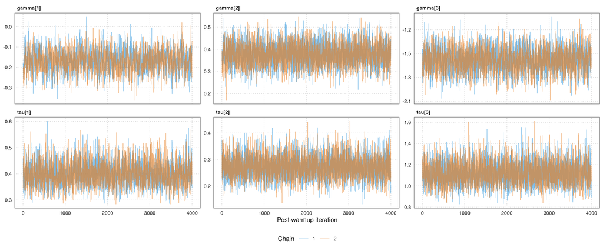

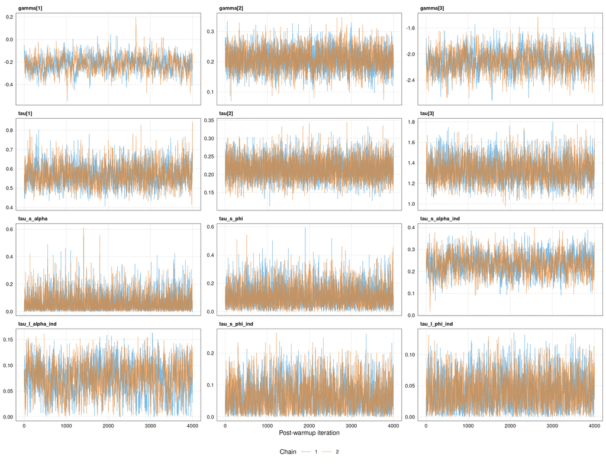

```r
# Population-average baseline parameters of both groups, on the 0-100 scale.
dplyr::bind_rows(lapply(c(0L, 1L), function(group) {
  fit <- fits_emp[[paste0(group_label(group), "_baseline")]]
  reconstruction <- reconstruct_baseline(extract_baseline_components(fit),
                                         fit$meta)
  purrr::imap_dfr(reconstruction$population, function(draws, parameter) {
    q <- posterior_summary(draws)
    tibble::tibble(group_label = group_label(group), parameter = parameter,
                   q2.5 = q[["q2.5"]], median = q[["median"]],
                   q97.5 = q[["q97.5"]])
  })
})) |>
  dplyr::select(group = group_label, parameter, q2.5, median, q97.5) |>
  kable(digits = 2,
        caption = "Population-average parameter estimates for the baseline-phase data (0-100 scale).")
```

Population-average parameter estimates for the baseline-phase data (0-100 scale).

| group | parameter | q2.5 | median | q97.5 |
| --- | --- | --- | --- | --- |
| control | alpha | 6.74 | 8.43 | 10.30 |
| control | phi | 0.22 | 0.30 | 0.38 |
| control | mean | 9.64 | 12.14 | 14.78 |
| control | innovation_variance | 81.20 | 126.87 | 229.30 |
| control | local_variance | 88.72 | 139.79 | 254.00 |
| control | sd | 9.42 | 11.82 | 15.94 |
| treatment | alpha | 4.41 | 5.54 | 6.87 |
| treatment | phi | 0.26 | 0.34 | 0.42 |
| treatment | mean | 6.61 | 8.47 | 10.59 |
| treatment | innovation_variance | 54.42 | 75.12 | 111.72 |
| treatment | local_variance | 60.75 | 85.38 | 129.14 |
| treatment | sd | 7.79 | 9.24 | 11.36 |

## 4.2 Population-average effect sizes for the intervention group

```r
# Within-group effect sizes of both groups (the control group is needed
# for the between-group contrast in Section 4.4).
results_emp <- list(
  control = run_group_posterior_analysis(
    fits_emp$control_baseline, fits_emp$control_intervention, 0L,
    "empirical/tables"),
  treatment = run_group_posterior_analysis(
    fits_emp$treatment_baseline, fits_emp$treatment_intervention, 1L,
    "empirical/tables"))
```

```r
# Integrated population-average effects of the intervention group.
results_emp$treatment$population_integrated_effects |>
  dplyr::filter(metric %in% PRIMARY_EFFECT_METRICS) |>
  dplyr::select(metric, q2.5, median, q97.5, credible_nonzero) |>
  kable(digits = 3,
        caption = "Integrated population-average effects, intervention group, empirical data.")
```

Integrated population-average effects, intervention group, empirical data.

| metric | q2.5 | median | q97.5 | credible_nonzero |
| --- | --- | --- | --- | --- |
| mean_standardized | -0.331 | -0.020 | 0.324 | FALSE |
| ar_difference | -0.246 | -0.148 | -0.049 | TRUE |
| local_variance_log_ratio | -0.929 | -0.361 | 0.231 | FALSE |

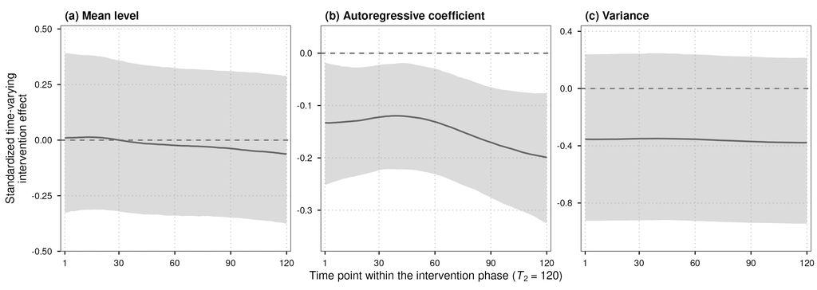

```r
# Population-average time-varying effects of the intervention group.
plot_trajectories_1x3(
  read.csv("empirical/tables/treatment_population_time_effects.csv"),
  "Standardized time-varying\nintervention effect",
  "empirical/figures/population_effects.png")
```

The integrated standardized mean effect is -0.02 (95% CrI [-0.33, 0.32]), whose CrI includes zero. The integrated autoregressive effect is -0.15 (95% CrI [-0.25, -0.05]) (CrI excludes zero), and the integrated variance effect is -0.36 (95% CrI [-0.93, 0.23]) (CrI includes zero).

## 4.3 Individual-specific effect sizes for the intervention group

```r
# compute_individual_time_effects(): individual-specific time-varying
# effects of one group's intervention participants.
#   models_dir : folder that holds the group's two fitted models
#   out_csv    : cache file; the computation runs only once
#   Returns, per person, metric, and time point, the posterior median and
#   95% CrI, plus the integrated-effect median used for sorting.
compute_individual_time_effects <- function(models_dir, out_csv) {
  if (!file.exists(out_csv)) {
    load_fit <- function(label) {
      md <- file.path(models_dir, label)
      list(fit = readRDS(file.path(md, "fit_object.rds")),
           meta = readRDS(file.path(md, "model_metadata.rds")))
    }
    tb <- load_fit("treatment_baseline")
    ti <- load_fit("treatment_intervention")
    bc <- extract_baseline_components(tb)
    ic <- extract_tvar_components(ti)
    D <- min(bc$n_draws, ic$n_draws)

    # Identical Monte-Carlo pairing as run_group_posterior_analysis(group = 1).
    set.seed(FORMAL_CONFIG$seed + 3000L + 1L)
    order_post <- sample.int(D)
    reorder_first <- function(x) {
      dims <- dim(x)
      if (is.null(dims)) return(x[order_post])
      args <- c(list(x, order_post), rep(list(TRUE), length(dims) - 1L),
                list(drop = FALSE))
      do.call(`[`, args)
    }
    for (name in setdiff(names(ic), "n_draws")) ic[[name]] <- reorder_first(ic[[name]])

    baseline <- reconstruct_baseline(bc, tb$meta)
    pop <- reconstruct_tvar_population(ic, ti$meta)
    pop_smooth <- pop$smooth
    time <- ti$meta$t_global

    # One pass per person: reconstruct the person's trajectories, build the
    # effect draws against their own baseline, and summarize per time point.
    rows <- vector("list", length(baseline$ids))
    for (i in seq_along(baseline$ids)) {
      id <- baseline$ids[[i]]
      post_i <- match(id, ti$meta$ids)
      base_i <- lapply(baseline$individual, function(x) x[, i])
      post_par <- reconstruct_tvar_individual(ic, ti$meta, post_i, pop_smooth)
      eff <- build_effect_draws(base_i, post_par)[METRICS]
      rows[[i]] <- purrr::imap_dfr(eff, function(draws, metric) {
        summarise_draw_matrix(draws, time) |>
          mutate(id = id, metric = metric,
                 integrated_median = stats::median(rowMeans(draws)), .before = 1)
      })
    }
    write_csv(bind_rows(rows), out_csv)
  }
  read.csv(out_csv)
}

emp_ind_time <- compute_individual_time_effects(
  "empirical/models", "empirical/figures/individual_time_effects.csv")
# Integrated effects with the credibility category used for coloring.
emp_ind_int <- read.csv("empirical/tables/treatment_individual_integrated_effects.csv") |>
  filter(metric %in% METRICS) |>
  mutate(category = case_when(
    !credible_nonzero ~ "ns", median > 0 ~ "pos", TRUE ~ "neg"))
```

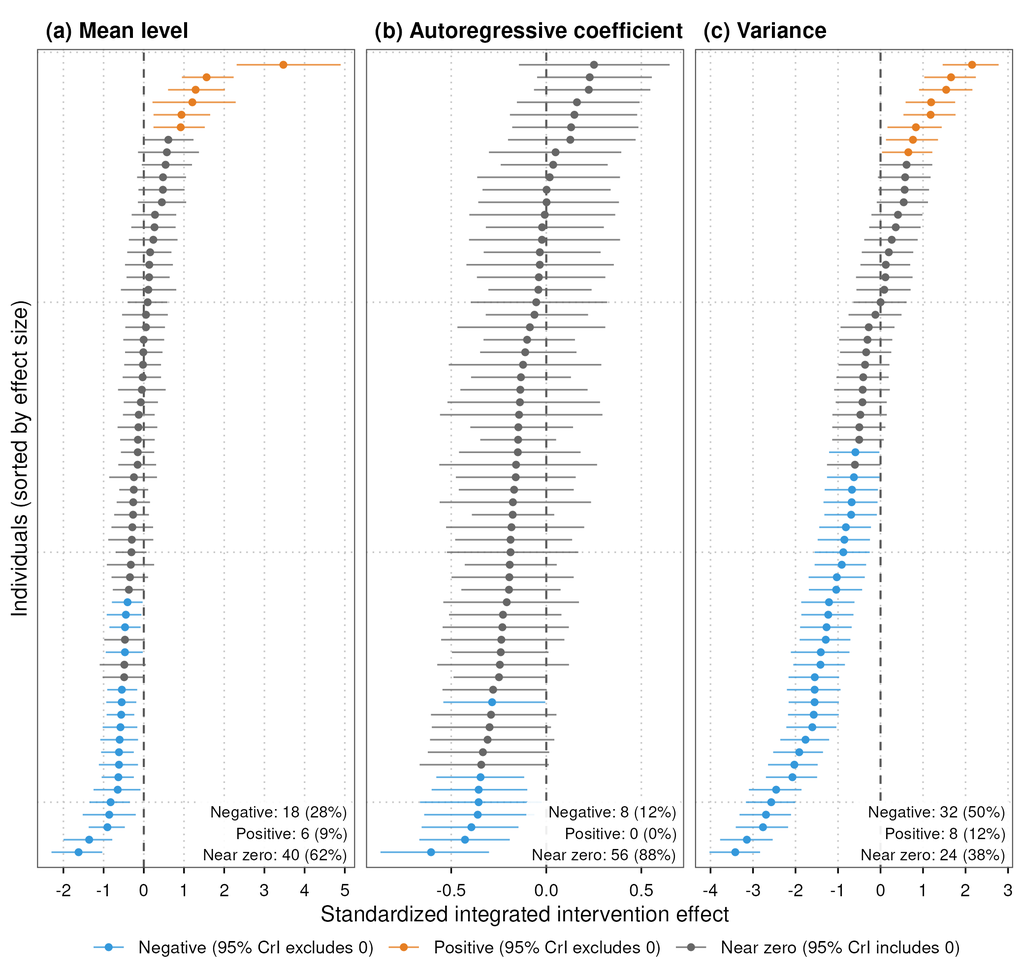

```r
# Forest plots of the individual integrated effects (same construction as
# for the simulated data in Section 6).
forest_data_emp <- emp_ind_int |>
  mutate(panel = factor(panel_labels[metric], levels = panel_labels),
         category = factor(category, levels = names(CAT_COLORS))) |>
  group_by(panel) |>
  arrange(desc(median), .by_group = TRUE) |>
  mutate(rank = row_number()) |>       # row position after sorting
  ungroup()
# Per-panel counts of the three credibility categories.
forest_ann_emp <- forest_data_emp |>
  count(panel, category, .drop = FALSE) |>
  group_by(panel) |>
  mutate(share = 100 * n / sum(n)) |>
  summarise(label = paste(sprintf(
    "%s: %d (%.0f%%)",
    recode(as.character(category), neg = "Negative", pos = "Positive",
           ns = "Near zero"), n, share), collapse = "\n"),
    .groups = "drop")
forest_breaks <- function(lims) {
  if (diff(lims) > 2.5) seq(floor(lims[1]), ceiling(lims[2]), by = 1) else
    scales::extended_breaks()(lims)
}
p_forest_emp <- ggplot(forest_data_emp, aes(median, rank)) +
  geom_vline(xintercept = 0, linetype = "dashed", color = "grey35",
             linewidth = 0.45) +
  geom_errorbarh(aes(xmin = q2.5, xmax = q97.5, color = category),
                 height = 0, linewidth = 0.35, alpha = 0.8) +
  geom_point(aes(color = category), size = 1.1) +
  geom_label(data = forest_ann_emp,
             aes(x = Inf, y = Inf, label = label),
             hjust = 1.02, vjust = -0.05, size = 2.6, lineheight = 1.1,
             color = "black", fill = "white", alpha = 0.9, label.size = 0,
             inherit.aes = FALSE) +
  scale_color_manual(values = CAT_COLORS, labels = CAT_LABELS, drop = FALSE) +
  scale_x_continuous(breaks = forest_breaks) +
  scale_y_reverse(expand = expansion(mult = 0.02)) +
  facet_wrap(~panel, ncol = 3, scales = "free_x") +
  labs(x = "Standardized integrated intervention effect",
       y = "Individuals (sorted by effect size)", color = NULL) +
  theme_paper() +
  theme(axis.text.y = element_blank(), axis.ticks.y = element_blank(),
        legend.box.spacing = unit(1, "pt"),
        legend.margin = margin(0, 0, 0, 0))
dir.create("empirical/figures", recursive = TRUE, showWarnings = FALSE)
ggsave("empirical/figures/individual_forest.png", p_forest_emp,
       width = 6.5, height = 6.2, dpi = 320, bg = "white")
```

Each row is one person, sorted by effect size, with the integrated effect computed against the person’s own baseline. On the standardized mean effect, 18 of the 64 persons (28%) show a credible decrease in negative affect and 6 show a credible increase.

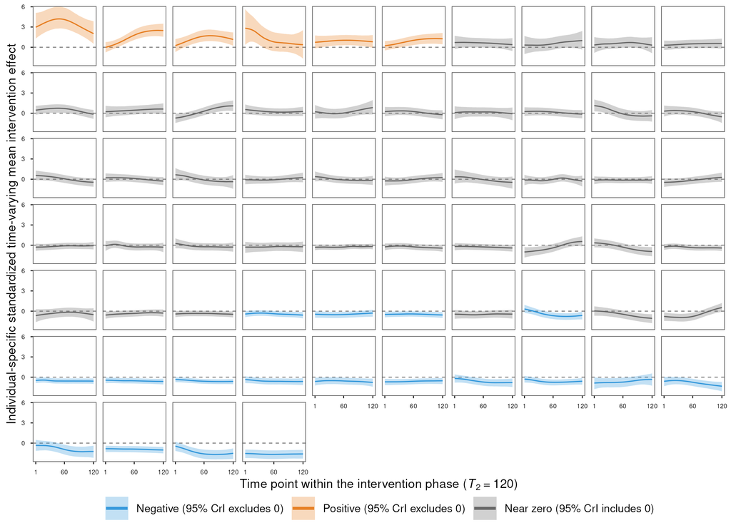

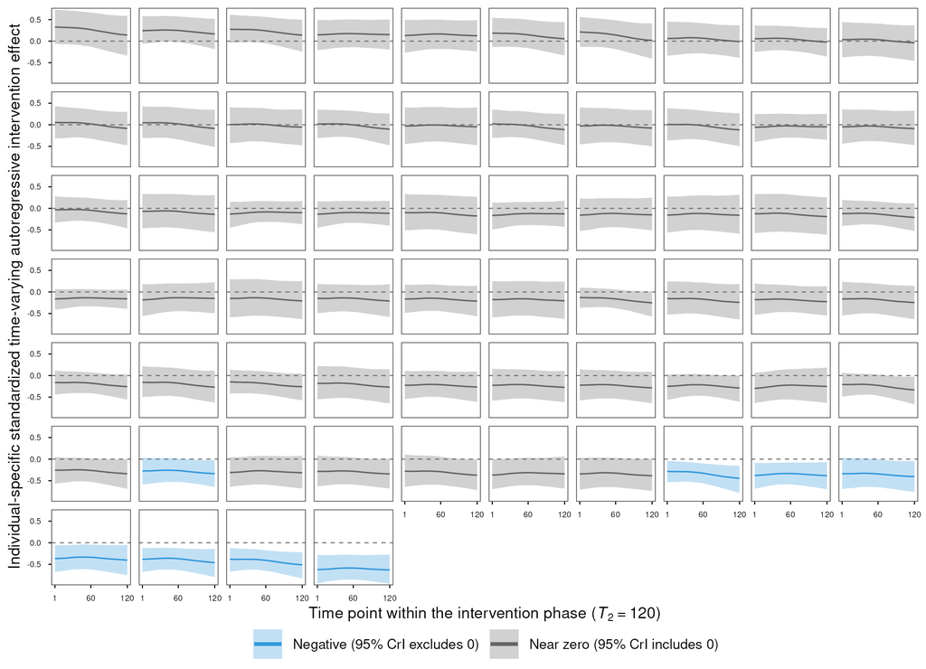

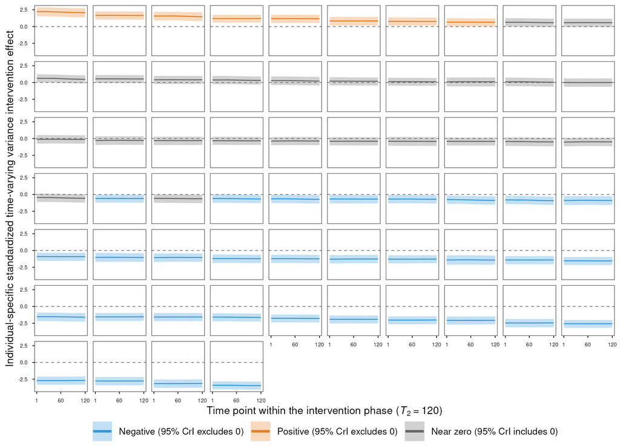

```r
# plot_individual_grid_data(): one small panel per person showing the time
# course of one effect metric with its 95% CrI.
#   ind_time_df : per-person time-varying summaries (from
#                 compute_individual_time_effects())
#   ind_int_df  : integrated effects with the credibility category
#   metric      : one of the three primary effect metrics
#   ylab / file : axis label and output PNG file
#   Panels are ordered by the integrated effect (largest first) and colored
#   by the forest-plot category of the person.
plot_individual_grid_data <- function(ind_time_df, ind_int_df, metric,
                                      ylab, file) {
  cat_m <- ind_int_df |> filter(metric == !!metric)
  d <- ind_time_df |>
    filter(metric == !!metric) |>
    mutate(tp = tp_of(time)) |>
    left_join(cat_m[, c("id", "category")], by = "id")
  ord <- d |> distinct(id, integrated_median) |>
    arrange(desc(integrated_median))          # largest effect first
  d <- d |> mutate(rank = factor(match(id, ord$id), levels = seq_len(nrow(ord))),
                   category = factor(category, levels = names(CAT_COLORS)))
  # Shared vertical limits, truncated at extreme values for readability.
  ylim <- c(stats::quantile(d$q2.5, 0.005), stats::quantile(d$q97.5, 0.995))
  p <- ggplot(d, aes(tp, median)) +
    geom_hline(yintercept = 0, linetype = "dashed", color = "grey45",
               linewidth = 0.25) +
    geom_ribbon(aes(ymin = q2.5, ymax = q97.5, fill = category),
                alpha = 0.3) +
    geom_line(aes(color = category), linewidth = 0.35) +
    facet_wrap(~rank, ncol = 10) +
    coord_cartesian(ylim = ylim) +
    scale_color_manual(values = CAT_COLORS, labels = CAT_LABELS,
                       drop = TRUE, name = NULL) +
    scale_fill_manual(values = CAT_COLORS, labels = CAT_LABELS,
                      drop = TRUE, name = NULL) +
    scale_x_continuous(breaks = c(1, 60, 120)) +
    scale_y_continuous(breaks = scales::breaks_extended(4)) +
    labs(x = X_LAB, y = ylab) +
    guides(color = guide_legend(override.aes = list(linewidth = 0.9))) +
    theme_paper(8) +
    theme(strip.text = element_blank(),
          axis.text = element_text(size = 4.2, color = "black"),
          axis.ticks = element_line(color = "black", linewidth = 0.25),
          axis.ticks.length = unit(1.5, "pt"),
          panel.spacing = unit(4, "pt"),
          panel.grid.major = element_blank(),
          panel.border = element_rect(color = "grey30", fill = NA,
                                      linewidth = 0.35),
          legend.box.spacing = unit(1, "pt"),
          legend.margin = margin(0, 0, 0, 0),
          legend.text = element_text(size = 7))
  # Height adapts to the number of panel rows (10 panels per row).
  n_rows <- ceiling(nrow(ord) / 10)
  dir.create(dirname(file), recursive = TRUE, showWarnings = FALSE)
  ggsave(file, p, width = 6.5, height = 0.5 * n_rows + 1.2, dpi = 320,
         bg = "white")
}
plot_individual_grid_data(emp_ind_time, emp_ind_int, "mean_standardized",
  "Individual-specific standardized time-varying mean intervention effect",
  "empirical/figures/individual_mean.png")
plot_individual_grid_data(emp_ind_time, emp_ind_int, "ar_difference",
  "Individual-specific standardized time-varying autoregressive intervention effect",
  "empirical/figures/individual_ar.png")
plot_individual_grid_data(emp_ind_time, emp_ind_int, "local_variance_log_ratio",
  "Individual-specific standardized time-varying variance intervention effect",
  "empirical/figures/individual_variance.png")
```

## 4.4 Between-group effect sizes

```r
# Between-group effects: intervention minus control, per posterior draw.
between_emp <- compute_between_group_effects(results_emp$treatment,
                                             results_emp$control,
                                             "empirical/tables")
```

```r
# Integrated between-group effects.
between_emp$integrated |>
  dplyr::filter(metric %in% PRIMARY_EFFECT_METRICS) |>
  dplyr::select(metric, q2.5, median, q97.5, credible_nonzero) |>
  kable(digits = 3,
        caption = "Integrated between-group effects, empirical data.")
```

Integrated between-group effects, empirical data.

| metric | q2.5 | median | q97.5 | credible_nonzero |
| --- | --- | --- | --- | --- |
| mean_standardized | -0.562 | -0.072 | 0.404 | FALSE |
| ar_difference | -0.204 | -0.060 | 0.084 | FALSE |
| local_variance_log_ratio | -1.627 | -0.519 | 0.488 | FALSE |

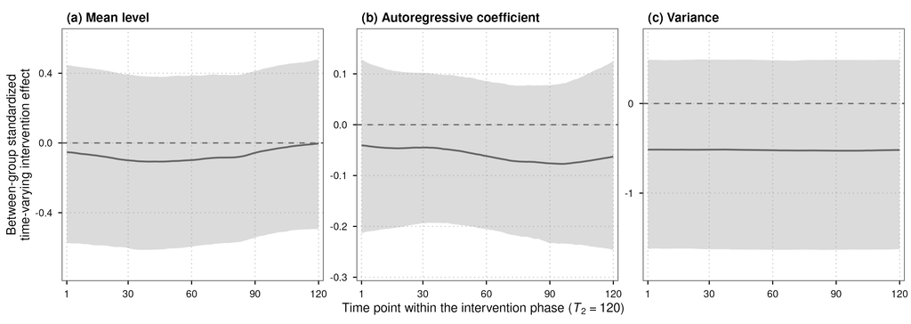

```r
# Between-group time-varying effects.
plot_trajectories_1x3(
  read.csv("empirical/tables/between_group_time_effects.csv"),
  "Between-group standardized\ntime-varying intervention effect",
  "empirical/figures/between_effects.png")
```

The integrated between-group effect on the mean is -0.07 (95% CrI [-0.56, 0.40]) (CrI includes zero). For inertia the integrated contrast is -0.06 (95% CrI [-0.20, 0.08]) (CrI includes zero), and for variability it is -0.52 (95% CrI [-1.63, 0.49]) (CrI includes zero).

# 5. Generation of the simulated dataset

The simulated dataset is generated from the joint posterior of the empirical models. Each of the 150 simulated participants per group is created by drawing person-specific parameters for both phases from the fitted posterior distributions, with the two phases linked so that each simulated participant keeps a consistent relative standing across baseline and intervention. The overnight blocks are set to missing and missingness is imposed at the empirical rates. Simulated participants whose observed within-phase standard deviation falls below 0.5 are redrawn from the posterior.

```r
# One simulated person = one 3-dimensional latent trait vector z shared by
# BOTH phases: the person's baseline random effects and intervention random
# effects are drawn from each phase's posterior Sigma_u at the same
# standardised position, which operationalises "the same individual" and
# gives individual baseline-vs-intervention contrasts their meaning.

# safe_mvrnorm(): draw correlated random effects at a given standardized
# position.
#   z     : 1 x 3 vector of standard-normal coordinates of the person
#   Sigma : 3 x 3 covariance matrix of the random effects
#   Returns z scaled by the Cholesky factor of Sigma (with a small ridge
#   added if Sigma is numerically non-positive-definite).
safe_mvrnorm <- function(z, Sigma) {
  Sigma <- (Sigma + t(Sigma)) / 2
  eig <- eigen(Sigma, symmetric = TRUE, only.values = TRUE)$values
  if (min(eig) <= 1e-10) Sigma <- Sigma + diag(abs(min(eig)) + 1e-8, 3)
  as.numeric(z %*% chol(Sigma))
}

# extract_generation_baseline() / extract_generation_tvar(): collect the
# posterior draws of one fitted model that the data generation needs
# (population means, random-effect covariance, and, for the TV-AR model,
# the population smooth coefficients and individual smoothing SDs).
extract_generation_baseline <- function(model_fit) {
  m <- posterior::as_draws_matrix(model_fit$fit$draws(
    variables = c("gamma", "Sigma_u")))
  list(gamma = extract_stan_array(m, "gamma", 3L),
       Sigma_u = extract_stan_array(m, "Sigma_u", c(3L, 3L)),
       n_draws = nrow(m))
}

extract_generation_tvar <- function(model_fit) {
  design <- model_fit$meta$design
  m <- posterior::as_draws_matrix(model_fit$fit$draws(variables = c(
    "gamma", "Sigma_u", "a_alpha", "a0_alpha", "a_phi", "a0_phi",
    "tau_s_alpha_ind", "tau_l_alpha_ind", "tau_s_phi_ind", "tau_l_phi_ind")))
  list(gamma = extract_stan_array(m, "gamma", 3L),
       Sigma_u = extract_stan_array(m, "Sigma_u", c(3L, 3L)),
       a_alpha = extract_stan_array(m, "a_alpha", ncol(design$alpha$Xr)),
       a0_alpha = extract_stan_array(m, "a0_alpha", ncol(design$alpha$Xf)),
       a_phi = extract_stan_array(m, "a_phi", ncol(design$phi$Xr)),
       a0_phi = extract_stan_array(m, "a0_phi", ncol(design$phi$Xf)),
       tau_s_alpha_ind = extract_stan_array(m, "tau_s_alpha_ind"),
       tau_l_alpha_ind = extract_stan_array(m, "tau_l_alpha_ind"),
       tau_s_phi_ind = extract_stan_array(m, "tau_s_phi_ind"),
       tau_l_phi_ind = extract_stan_array(m, "tau_l_phi_ind"),
       n_draws = nrow(m))
}

# simulate_baseline_phase(): simulate the baseline series of n_people
# persons on the z scale.
#   generative : output of extract_generation_baseline()
#   meta       : metadata of the fitted baseline model
#   n_people   : number of persons to simulate
#   z_re       : n_people x 3 matrix of standardized random-effect positions
#   draw_index : posterior draw used for each person
#   Each person's random effects are drawn from the posterior Sigma_u at
#   their position z, the series starts from the stationary distribution,
#   and the AR(1) recursion is iterated forward. Returns an n_people x Tnum
#   matrix.
simulate_baseline_phase <- function(generative, meta, n_people, z_re,
                                    draw_index) {
  Tnum <- length(meta$t_global)
  y <- matrix(NA_real_, n_people, Tnum)
  for (i in seq_len(n_people)) {
    d <- draw_index[i]
    u <- safe_mvrnorm(z_re[i, ], generative$Sigma_u[d, , ])
    alpha <- generative$gamma[d, 1] + u[1]
    phi <- FORMAL_CONFIG$phi_max * tanh(generative$gamma[d, 2] + u[2])
    innovation_sd <- sqrt(exp(generative$gamma[d, 3] + u[3]))
    attractor <- alpha / (1 - phi)
    y[i, 1] <- stats::rnorm(1, attractor, innovation_sd / sqrt(1 - phi^2))
    for (t in 2:Tnum) {
      y[i, t] <- alpha + phi * y[i, t - 1] + stats::rnorm(1, 0, innovation_sd)
    }
  }
  y
}

# simulate_tvar_phase(): simulate the intervention-phase series of
# n_people persons on the z scale (arguments as in
# simulate_baseline_phase(), with generative from
# extract_generation_tvar()). The population alpha(t) and phi(t) smooths
# come from the person's posterior draw, and the person's own smooth
# deviations are drawn from their estimated population distribution.
simulate_tvar_phase <- function(generative, meta, n_people, z_re, draw_index) {
  design <- meta$design
  Tnum <- length(meta$t_global)
  y <- matrix(NA_real_, n_people, Tnum)
  for (i in seq_len(n_people)) {
    d <- draw_index[i]
    u <- safe_mvrnorm(z_re[i, ], generative$Sigma_u[d, , ])
    pop_alpha <- as.numeric(design$alpha$Xr %*% generative$a_alpha[d, ] +
                              design$alpha$Xf %*% generative$a0_alpha[d, ])
    pop_phi <- as.numeric(design$phi$Xr %*% generative$a_phi[d, ] +
                            design$phi$Xf %*% generative$a0_phi[d, ])
    ind_alpha <- as.numeric(
      design$alpha_ind$Xr %*% (stats::rnorm(ncol(design$alpha_ind$Xr)) *
                                 generative$tau_s_alpha_ind[d]) +
      design$alpha_ind$Xf %*% (stats::rnorm(ncol(design$alpha_ind$Xf)) *
                                 generative$tau_l_alpha_ind[d]))
    ind_phi <- as.numeric(
      design$phi_ind$Xr %*% (stats::rnorm(ncol(design$phi_ind$Xr)) *
                               generative$tau_s_phi_ind[d]) +
      design$phi_ind$Xf %*% (stats::rnorm(ncol(design$phi_ind$Xf)) *
                               generative$tau_l_phi_ind[d]))
    alpha <- generative$gamma[d, 1] + u[1] + pop_alpha + ind_alpha
    phi <- FORMAL_CONFIG$phi_max * tanh(generative$gamma[d, 2] + u[2] +
                                          pop_phi + ind_phi)
    innovation_sd <- sqrt(exp(generative$gamma[d, 3] + u[3]))
    y[i, 1] <- stats::rnorm(1, alpha[1] / (1 - phi[1]),
                            innovation_sd / sqrt(1 - phi[1]^2))
    for (t in 2:Tnum) {
      y[i, t] <- alpha[t] + phi[t] * y[i, t - 1] +
        stats::rnorm(1, 0, innovation_sd)
    }
  }
  y
}

# person_series_to_bounded(): convert one person's simulated z-scale
# series (both phases) back to the bounded 0-100 scale.
#   y_base / y_post : simulated baseline and intervention series (z scale)
#   scaling         : list(center, scale) of the common standardization
#   Returns list(unbounded, bounded); values outside [0, 100] are clipped
#   and the clipping rate is reported as a generation diagnostic.
person_series_to_bounded <- function(y_base, y_post, scaling) {
  raw <- scaling$center + scaling$scale * c(y_base, y_post)
  list(unbounded = raw, bounded = pmin(pmax(raw, 0), 100))
}
```

```r
# generate_synthetic_cohort(): generate the complete simulated cohort.
#   empirical : list with element `fits` (the four fitted empirical models)
#   real_data : the screened empirical data (for the missingness rates)
#   out_dir   : folder for the cohort files and generation diagnostics
#   Returns the simulated cohort in long format. Workflow:
#   (1) per group, draw 150 persons (shared-z linkage, posterior draws);
#   (2) assemble the long-format grid, clip to [0, 100];
#   (3) impose the structural beep-5/6 gaps and MCAR missingness at the
#       empirical group x phase rates;
#   (4) redraw any person whose observed within-phase SD is below
#       SYNTHETIC_MIN_OBSERVED_SD (missingness positions
#       stay fixed) so the demonstration cohort samples efficiently;
#   (5) write the dataset plus generation diagnostics.
generate_synthetic_cohort <- function(empirical, real_data, out_dir) {
  dir.create(out_dir, recursive = TRUE, showWarnings = FALSE)
  fits <- empirical$fits
  scaling <- fits$control_baseline$meta$scaling
  n <- FORMAL_CONFIG$synthetic_n_per_group
  set.seed(FORMAL_CONFIG$seed + 5000L)

  gens <- list()
  pieces <- list()
  for (group in c(0L, 1L)) {
    glabel <- group_label(group)
    base_fit <- fits[[paste0(glabel, "_baseline")]]
    post_fit <- fits[[paste0(glabel, "_intervention")]]
    gens[[glabel]] <- list(
      base = extract_generation_baseline(base_fit),
      post = extract_generation_tvar(post_fit),
      base_meta = base_fit$meta, post_meta = post_fit$meta)
    z_re <- matrix(stats::rnorm(n * 3L), n, 3L)
    base_idx <- sample.int(gens[[glabel]]$base$n_draws, n, replace = TRUE)
    post_idx <- sample.int(gens[[glabel]]$post$n_draws, n, replace = TRUE)
    base_y <- simulate_baseline_phase(gens[[glabel]]$base,
                                      gens[[glabel]]$base_meta, n, z_re,
                                      base_idx)
    post_y <- simulate_tvar_phase(gens[[glabel]]$post,
                                  gens[[glabel]]$post_meta, n, z_re, post_idx)
    ids <- (group + 1L) * 100000L + seq_len(n)
    for (i in seq_len(n)) {
      series <- person_series_to_bounded(base_y[i, ], post_y[i, ], scaling)
      pieces[[length(pieces) + 1L]] <- tibble::tibble(
        id = ids[i], group = group,
        t = c(BASELINE_T, INTERVENTION_T)) |>
        dplyr::mutate(
          day = (.data$t - 1L) %/% BEEPS_PER_DAY + 1L,
          beep = (.data$t - 1L) %% BEEPS_PER_DAY + 1L,
          phase = as.integer(.data$day > BASELINE_DAYS),
          structural_slot = !(.data$beep %in% AUTHENTIC_BEEPS),
          authentic_slot = .data$beep %in% AUTHENTIC_BEEPS,
          value_unbounded = series$unbounded, value = series$bounded)
    }
  }
  synthetic <- dplyr::bind_rows(pieces) |> dplyr::arrange(.data$id, .data$t)

  # Step 3: structural gaps + MCAR missingness at the empirical rates.
  rates <- real_data |>
    dplyr::filter(.data$authentic_slot) |>
    dplyr::group_by(.data$group, .data$phase) |>
    dplyr::summarise(rate = mean(is.na(.data$value)), .groups = "drop")
  synthetic$value[synthetic$structural_slot] <- NA_real_
  set.seed(FORMAL_CONFIG$seed + 5099L)
  for (row in seq_len(nrow(rates))) {
    eligible <- which(synthetic$group == rates$group[row] &
                        synthetic$phase == rates$phase[row] &
                        synthetic$authentic_slot)
    n_missing <- round(length(eligible) * rates$rate[row])
    if (n_missing > 0) {
      synthetic$value[sample(eligible, n_missing)] <- NA_real_
    }
  }

  # Step 4: unified low-variability rule, enforced by whole-person redraws
  # (the person's missing POSITIONS never change, only the values).
  redraw_counts <- c(control = 0L, treatment = 0L)
  rounds <- 0L
  repeat {
    observed_sd <- synthetic |>
      dplyr::filter(.data$authentic_slot, !is.na(.data$value)) |>
      dplyr::group_by(.data$group, .data$phase, .data$id) |>
      dplyr::summarise(sd = stats::sd(.data$value), .groups = "drop")
    bad <- observed_sd |>
      dplyr::filter(is.na(.data$sd) | .data$sd < SYNTHETIC_MIN_OBSERVED_SD) |>
      dplyr::distinct(.data$group, .data$id)
    if (nrow(bad) == 0L) break
    rounds <- rounds + 1L
    stopifnot("redraw did not converge in 100 rounds" = rounds <= 100L)
    for (row in seq_len(nrow(bad))) {
      g <- bad$group[row]
      glabel <- group_label(g)
      redraw_counts[glabel] <- redraw_counts[glabel] + 1L
      gen <- gens[[glabel]]
      z_new <- matrix(stats::rnorm(3L), 1L, 3L)
      yb <- simulate_baseline_phase(gen$base, gen$base_meta, 1L, z_new,
                                    sample.int(gen$base$n_draws, 1L))
      yp <- simulate_tvar_phase(gen$post, gen$post_meta, 1L, z_new,
                                sample.int(gen$post$n_draws, 1L))
      series <- person_series_to_bounded(yb[1L, ], yp[1L, ], scaling)
      rows_i <- which(synthetic$id == bad$id[row])   # sorted by t
      na_mask <- is.na(synthetic$value[rows_i])
      synthetic$value_unbounded[rows_i] <- series$unbounded
      synthetic$value[rows_i] <- ifelse(na_mask, NA_real_, series$bounded)
    }
  }

  # Step 5: dataset + diagnostics.
  clipping <- synthetic |>
    dplyr::group_by(.data$group, .data$phase) |>
    dplyr::summarise(
      values = dplyr::n(),
      clipped_low = sum(.data$value_unbounded < 0),
      clipped_high = sum(.data$value_unbounded > 100),
      clipping_rate = mean(.data$value_unbounded < 0 |
                             .data$value_unbounded > 100),
      .groups = "drop")
  write_csv(clipping, file.path(out_dir, "generation_clipping_diagnostic.csv"))
  write_csv(tibble::tibble(group = names(redraw_counts),
                           redrawn_persons = as.integer(redraw_counts),
                           redraw_rounds = rounds,
                           min_observed_sd = SYNTHETIC_MIN_OBSERVED_SD),
            file.path(out_dir, "generation_redraw_diagnostic.csv"))
  write_csv(rates, file.path(out_dir, "generation_mcar_rates.csv"))
  saveRDS(synthetic, file.path(out_dir, "synthetic_cohort.rds"),
          compress = "xz")
  write_csv(synthetic, file.path(out_dir, "synthetic_cohort.csv"))
  synthetic
}
```

```r
# Redraw threshold for near-constant simulated persons (0-100 scale).
SYNTHETIC_MIN_OBSERVED_SD <- 0.5

# Generate the cohort (skipped when simulated_data.csv already exists),
# then keep the shareable columns.
if (!file.exists("simulated_data.csv")) {
  cohort <- generate_synthetic_cohort(list(fits = fits_emp), empirical_data,
                                      "generation")
  simulated <- cohort[, c("id", "group", "day", "beep", "t", "phase", "value")]
  write.csv(simulated, "simulated_data.csv", row.names = FALSE, na = "")
}
```

# 6. Analysis of the simulated dataset

This section repeats, for completeness, the analysis of the simulated dataset that the tutorial walks through step by step. The code and the results are identical to the tutorial.

```r
# Load the simulated dataset and flag the scheduled assessment slots.
synthetic <- read.csv("simulated_data.csv") |>
  # beeps 5 and 6 are the inserted overnight blocks
  dplyr::mutate(authentic_slot = beep %in% AUTHENTIC_BEEPS)
```

```r
overview <- synthetic |>
  dplyr::filter(authentic_slot) |>
  dplyr::group_by(group, phase) |>
  dplyr::summarise(persons = dplyr::n_distinct(id),
                   observed = sum(!is.na(value)),
                   missing_rate = mean(is.na(value)),
                   observed_mean = mean(value, na.rm = TRUE),
                   observed_sd = stats::sd(value, na.rm = TRUE),
                   .groups = "drop") |>
  dplyr::mutate(group = group_label(group), phase = phase_label(phase))
kable(overview, digits = 3,
      caption = "Descriptive overview by group and phase.")
```

Descriptive overview by group and phase.

| group | phase | persons | observed | missing_rate | observed_mean | observed_sd |
| --- | --- | --- | --- | --- | --- | --- |
| control | baseline | 150 | 4543 | 0.054 | 15.460 | 15.713 |
| control | intervention | 150 | 11352 | 0.054 | 16.111 | 16.224 |
| treatment | baseline | 150 | 4620 | 0.038 | 11.447 | 11.414 |
| treatment | intervention | 150 | 11494 | 0.042 | 10.894 | 11.185 |

```r
# Common z-standardization constants from the pooled baseline observations.
scaling <- compute_common_scaling(synthetic)
unlist(scaling)
```

```
#>   center    scale
#> 13.43690 13.86045
```

```r
# Persons-by-time input matrix for each group and phase.
phase_matrices <- list()
for (group in c(0L, 1L)) for (phase in c(0L, 1L)) {
  name <- paste(group_label(group), phase_label(phase), sep = "_")
  phase_matrices[[name]] <- prepare_phase_matrix(synthetic, group, phase,
                                                 scaling)
}
```

```r
# Fit (or re-load) the four models: two groups by two phases.
fits <- list()
for (name in names(phase_matrices)) {
  pm <- phase_matrices[[name]]
  fits[[name]] <- fit_phase_model(pm, compiled, ".",
                                  seed_offset = 200L + pm$group * 2L + pm$phase)
}
```

```r
# One-row convergence summary per model.
diagnostics <- purrr::imap_dfr(fits, function(x, model) {
  dplyr::mutate(x$diagnostics, model = model, .before = 1)
})
diagnostics |>
  dplyr::select(model, max_rhat, min_ess_bulk, min_ess_tail) |>
  kable(digits = 3, caption = "Convergence diagnostics for the four models.")
```

Convergence diagnostics for the four models.

| model | max_rhat | min_ess_bulk | min_ess_tail |
| --- | --- | --- | --- |
| control_baseline | 1.008 | 581.082 | 1435.648 |
| control_intervention | 1.009 | 209.556 | 420.829 |
| treatment_baseline | 1.002 | 714.533 | 1408.978 |
| treatment_intervention | 1.006 | 349.920 | 804.561 |

```r
# Population-average baseline parameters of both groups, on the 0-100 scale.
baseline_population <- dplyr::bind_rows(lapply(c(0L, 1L), function(group) {
  fit <- fits[[paste0(group_label(group), "_baseline")]]
  reconstruction <- reconstruct_baseline(extract_baseline_components(fit),
                                         fit$meta)
  purrr::imap_dfr(reconstruction$population, function(draws, parameter) {
    q <- posterior_summary(draws)
    tibble::tibble(group_label = group_label(group), parameter = parameter,
                   q2.5 = q[["q2.5"]], median = q[["median"]],
                   q97.5 = q[["q97.5"]])
  })
}))
baseline_population |>
  dplyr::select(group = group_label, parameter, q2.5, median, q97.5) |>
  kable(digits = 2,
        caption = "Population-average parameter estimates for the baseline-phase data (0-100 scale).")
```

Population-average parameter estimates for the baseline-phase data (0-100 scale).

| group | parameter | q2.5 | median | q97.5 |
| --- | --- | --- | --- | --- |
| control | alpha | 8.27 | 9.21 | 10.19 |
| control | phi | 0.26 | 0.31 | 0.36 |
| control | mean | 11.97 | 13.42 | 14.83 |
| control | innovation_variance | 83.39 | 109.30 | 149.36 |
| control | local_variance | 92.20 | 121.23 | 166.41 |
| control | sd | 9.60 | 11.01 | 12.90 |
| treatment | alpha | 5.68 | 6.26 | 6.88 |
| treatment | phi | 0.32 | 0.36 | 0.40 |
| treatment | mean | 8.83 | 9.83 | 10.86 |
| treatment | innovation_variance | 46.90 | 56.53 | 69.43 |
| treatment | local_variance | 53.60 | 65.15 | 80.52 |
| treatment | sd | 7.32 | 8.07 | 8.97 |

```r
# Within-group effect sizes of both groups (the control group is needed
# for the between-group contrast in Section 5.4).
tables_dir <- "tables"
results <- list(
  control = run_group_posterior_analysis(
    fits$control_baseline, fits$control_intervention, 0L, tables_dir),
  treatment = run_group_posterior_analysis(
    fits$treatment_baseline, fits$treatment_intervention, 1L, tables_dir))
```

```r
# Integrated population-average effects of the intervention group.
results$treatment$population_integrated_effects |>
  dplyr::filter(metric %in% PRIMARY_EFFECT_METRICS) |>
  dplyr::select(metric, q2.5, median, q97.5, credible_nonzero) |>
  kable(digits = 3,
        caption = "Integrated population-average effects, intervention group.")
```

Integrated population-average effects, intervention group.

| metric | q2.5 | median | q97.5 | credible_nonzero |
| --- | --- | --- | --- | --- |
| mean_standardized | -0.202 | -0.017 | 0.180 | FALSE |
| ar_difference | -0.235 | -0.177 | -0.118 | TRUE |
| local_variance_log_ratio | -0.695 | -0.350 | 0.016 | FALSE |

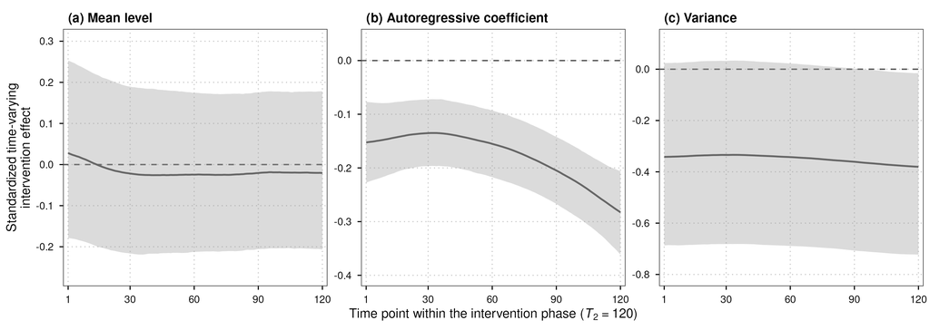

```r
# Population-average time-varying intervention effects, intervention group.
plot_trajectories_1x3(
  read.csv(file.path("tables",
                     "treatment_population_time_effects.csv")),
  "Standardized time-varying\nintervention effect",
  file.path(FIG_DIR, "figure3.png"))
```

The integrated standardized mean effect is -0.02 (95% CrI [-0.20, 0.18]), indicating no discernible shift in the mean level, and the time-varying trajectory (panel a) remains close to zero throughout. The integrated autoregressive effect is -0.18 (95% CrI [-0.23, -0.12]), a credible reduction in inertia, and its trajectory (panel b) is credible from the start of the phase onward. The integrated variance effect is -0.35 (95% CrI [-0.69, 0.02]), and its trajectory (panel c) drifts downward gradually and becomes credible only in the later part of the phase.

```r
# Individual-specific time-varying effects for the intervention group,
# computed once and cached as a CSV; later runs load the cache.
csv_path <- file.path(FIG_DIR, "treatment_individual_time_effects.csv")
if (!file.exists(csv_path)) {
  load_fit <- function(label) {
    md <- file.path("models", label)
    list(fit = readRDS(file.path(md, "fit_object.rds")),
         meta = readRDS(file.path(md, "model_metadata.rds")))
  }
  tb <- load_fit("treatment_baseline")
  ti <- load_fit("treatment_intervention")
  bc <- extract_baseline_components(tb)
  ic <- extract_tvar_components(ti)
  D <- min(bc$n_draws, ic$n_draws)

  # Identical Monte-Carlo pairing as run_group_posterior_analysis(group = 1)
  set.seed(FORMAL_CONFIG$seed + 3000L + 1L)
  order_post <- sample.int(D)
  reorder_first <- function(x) {
    dims <- dim(x)
    if (is.null(dims)) return(x[order_post])
    args <- c(list(x, order_post), rep(list(TRUE), length(dims) - 1L),
              list(drop = FALSE))
    do.call(`[`, args)
  }
  for (name in setdiff(names(ic), "n_draws")) ic[[name]] <- reorder_first(ic[[name]])

  baseline <- reconstruct_baseline(bc, tb$meta)
  pop <- reconstruct_tvar_population(ic, ti$meta)
  pop_smooth <- pop$smooth
  time <- ti$meta$t_global

  rows <- vector("list", length(baseline$ids))
  for (i in seq_along(baseline$ids)) {
    id <- baseline$ids[[i]]
    post_i <- match(id, ti$meta$ids)
    base_i <- lapply(baseline$individual, function(x) x[, i])
    post_par <- reconstruct_tvar_individual(ic, ti$meta, post_i, pop_smooth)
    eff <- build_effect_draws(base_i, post_par)[METRICS]
    rows[[i]] <- purrr::imap_dfr(eff, function(draws, metric) {
      summarise_draw_matrix(draws, time) |>
        mutate(id = id, metric = metric,
               integrated_median = stats::median(rowMeans(draws)), .before = 1)
    })
  }
  write_csv(bind_rows(rows), csv_path)
}
ind_time <- read.csv(csv_path)
ind_int <- read.csv(file.path("tables",
                              "treatment_individual_integrated_effects.csv")) |>
  filter(metric %in% METRICS) |>
  mutate(category = case_when(
    !credible_nonzero ~ "ns", median > 0 ~ "pos", TRUE ~ "neg"))
```

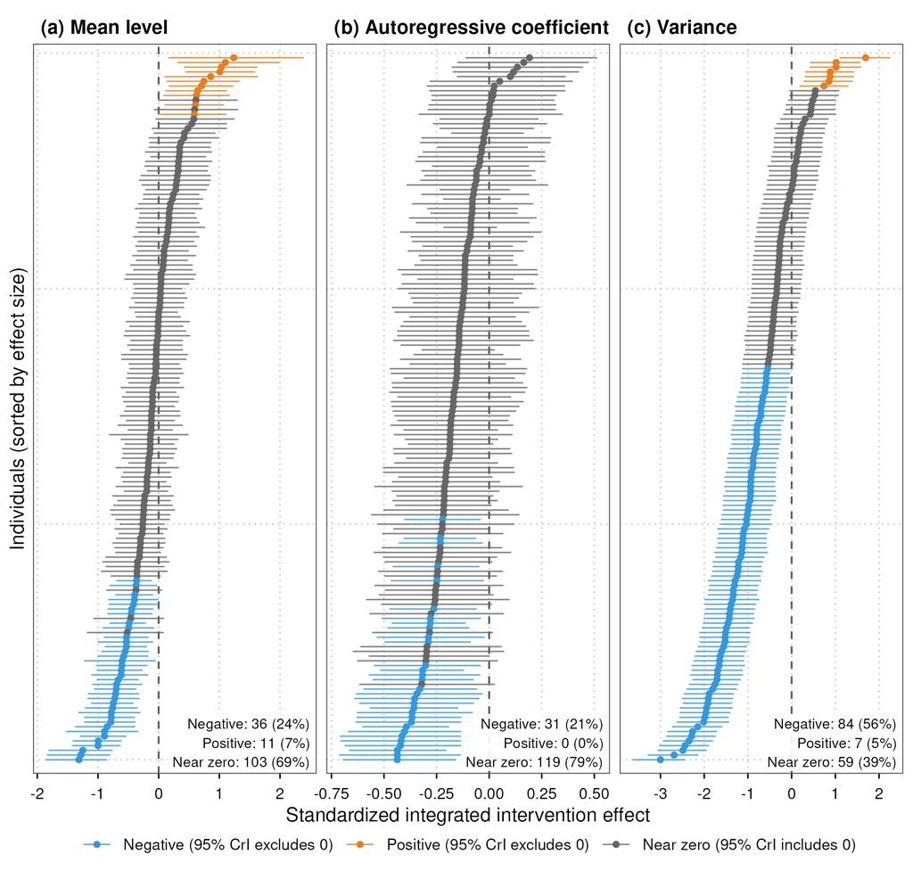

```r
# Individual-specific standardized integrated effects (forest plots).
forest_data <- ind_int |>
  mutate(panel = factor(panel_labels[metric], levels = panel_labels),
         category = factor(category, levels = names(CAT_COLORS))) |>
  group_by(panel) |>
  arrange(desc(median), .by_group = TRUE) |>
  mutate(rank = row_number()) |>
  ungroup()
forest_ann <- forest_data |>
  count(panel, category, .drop = FALSE) |>
  group_by(panel) |>
  mutate(share = 100 * n / sum(n)) |>
  summarise(label = paste(sprintf(
    "%s: %d (%.0f%%)",
    recode(as.character(category), neg = "Negative", pos = "Positive",
           ns = "Near zero"), n, share), collapse = "\n"),
    .groups = "drop")
forest_breaks <- function(lims) {
  if (diff(lims) > 2.5) seq(floor(lims[1]), ceiling(lims[2]), by = 1) else
    scales::extended_breaks()(lims)
}
p_forest <- ggplot(forest_data, aes(median, rank)) +
  geom_vline(xintercept = 0, linetype = "dashed", color = "grey35",
             linewidth = 0.45) +
  geom_errorbarh(aes(xmin = q2.5, xmax = q97.5, color = category),
                 height = 0, linewidth = 0.35, alpha = 0.8) +
  geom_point(aes(color = category), size = 1.1) +
  geom_label(data = forest_ann,
             aes(x = Inf, y = Inf, label = label),
             hjust = 1.02, vjust = -0.05, size = 2.6, lineheight = 1.1,
             color = "black", fill = "white", alpha = 0.9, label.size = 0,
             inherit.aes = FALSE) +
  scale_color_manual(values = CAT_COLORS, labels = CAT_LABELS, drop = FALSE) +
  scale_x_continuous(breaks = forest_breaks) +
  scale_y_reverse(expand = expansion(mult = 0.02)) +
  facet_wrap(~panel, ncol = 3, scales = "free_x") +
  labs(x = "Standardized integrated intervention effect",
       y = "Individuals (sorted by effect size)", color = NULL) +
  theme_paper() +
  theme(axis.text.y = element_blank(), axis.ticks.y = element_blank(),
        legend.box.spacing = unit(1, "pt"),
        legend.margin = margin(0, 0, 0, 0))
ggsave(file.path(FIG_DIR, "figure4.png"), p_forest, width = 6.5,
       height = 6.2, dpi = 320, bg = "white")
```

Each row is one person, sorted by effect size, with the integrated effect computed against the person’s own baseline. On the standardized mean effect, 36 of the 150 persons (24%) show a credible decrease in negative affect and 11 show a credible increase.

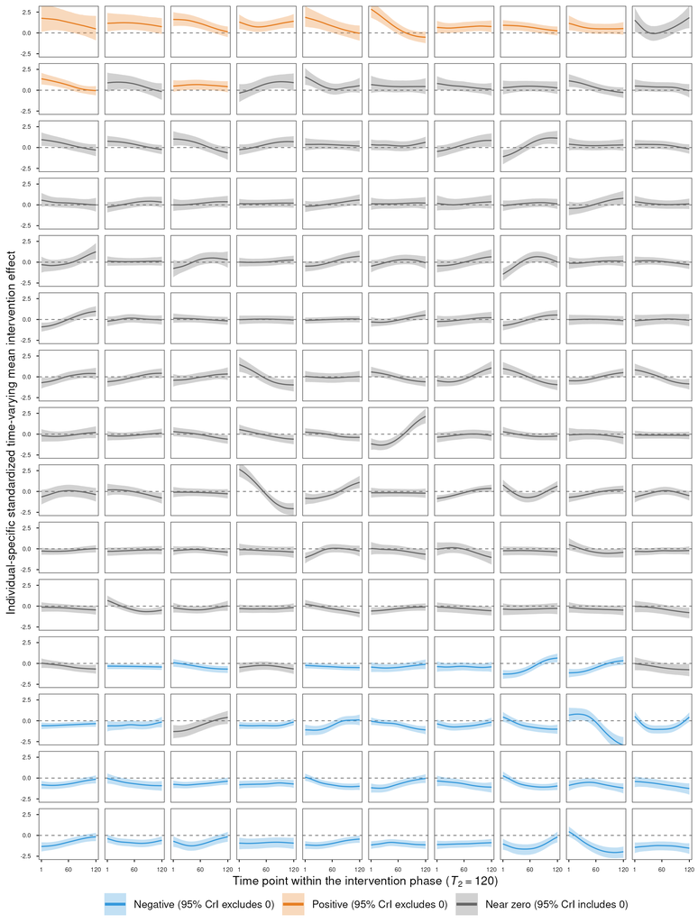

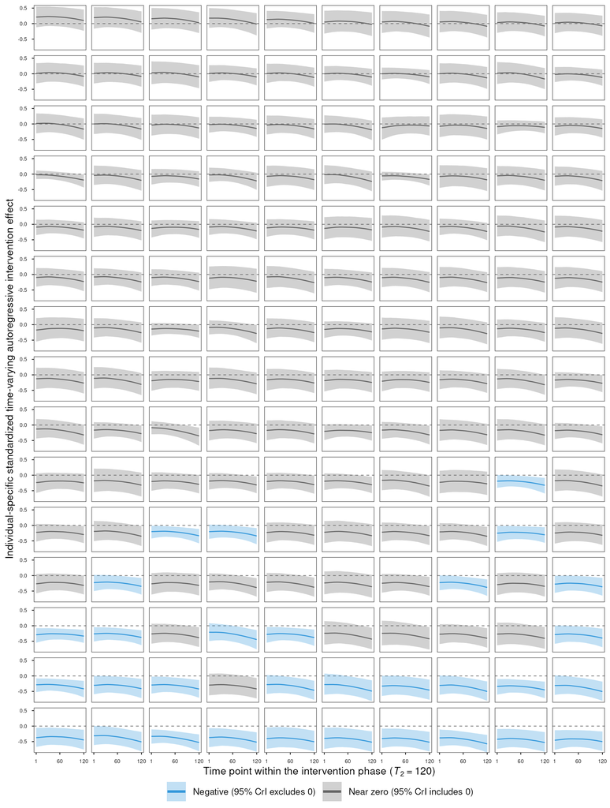

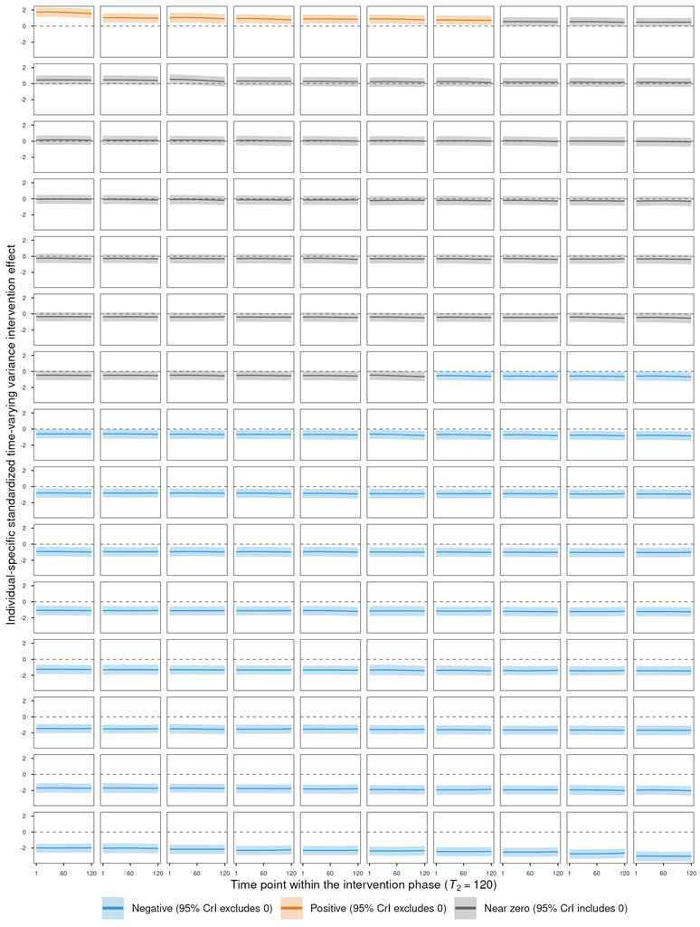

```r
# Individual time-varying effects, one small panel per person, ordered by
# the integrated effect and colored by the forest-plot category.
# plot_individual_grid(): one small panel per person showing the time
# course of one effect metric with its 95% CrI.
#   metric : one of the three primary effect metrics
#   ylab   : label of the vertical axis
#   file   : output PNG file
#   Panels are ordered by the integrated effect (largest first) and colored
#   by the forest-plot category of the person.
plot_individual_grid <- function(metric, ylab, file) {
  cat_m <- ind_int |> filter(metric == !!metric)
  d <- ind_time |>
    filter(metric == !!metric) |>
    mutate(tp = tp_of(time)) |>
    left_join(cat_m[, c("id", "category")], by = "id")
  ord <- d |> distinct(id, integrated_median) |>
    arrange(desc(integrated_median))          # largest effect first
  d <- d |> mutate(rank = factor(match(id, ord$id), levels = seq_len(nrow(ord))),
                   category = factor(category, levels = names(CAT_COLORS)))
  ylim <- c(stats::quantile(d$q2.5, 0.005), stats::quantile(d$q97.5, 0.995))
  p <- ggplot(d, aes(tp, median)) +
    geom_hline(yintercept = 0, linetype = "dashed", color = "grey45",
               linewidth = 0.25) +
    geom_ribbon(aes(ymin = q2.5, ymax = q97.5, fill = category),
                alpha = 0.3) +
    geom_line(aes(color = category), linewidth = 0.35) +
    facet_wrap(~rank, ncol = 10) +
    coord_cartesian(ylim = ylim) +
    scale_color_manual(values = CAT_COLORS, labels = CAT_LABELS,
                       drop = TRUE, name = NULL) +
    scale_fill_manual(values = CAT_COLORS, labels = CAT_LABELS,
                      drop = TRUE, name = NULL) +
    scale_x_continuous(breaks = c(1, 60, 120)) +
    scale_y_continuous(breaks = scales::breaks_extended(4)) +
    labs(x = X_LAB, y = ylab) +
    guides(color = guide_legend(override.aes = list(linewidth = 0.9))) +
    theme_paper(8) +
    theme(strip.text = element_blank(),
          axis.text = element_text(size = 4.2, color = "black"),
          axis.ticks = element_line(color = "black", linewidth = 0.25),
          axis.ticks.length = unit(1.5, "pt"),
          panel.spacing = unit(4, "pt"),
          panel.grid.major = element_blank(),
          panel.border = element_rect(color = "grey30", fill = NA,
                                      linewidth = 0.35),
          legend.box.spacing = unit(1, "pt"),
          legend.margin = margin(0, 0, 0, 0),
          legend.text = element_text(size = 7))
  dir.create(dirname(file), recursive = TRUE, showWarnings = FALSE)
  ggsave(file, p, width = 6.5, height = 8.6, dpi = 320, bg = "white")
}
plot_individual_grid("mean_standardized",
  "Individual-specific standardized time-varying mean intervention effect",
  file.path(FIG_DIR, "figure5.png"))
plot_individual_grid("ar_difference",
  "Individual-specific standardized time-varying autoregressive intervention effect",
  file.path(FIG_DIR, "figure_S1_individual_ar.png"))
plot_individual_grid("local_variance_log_ratio",
  "Individual-specific standardized time-varying variance intervention effect",
  file.path(FIG_DIR, "figure_S2_individual_variance.png"))
```

```r
# Between-group effects: intervention minus control, per posterior draw.
between <- compute_between_group_effects(results$treatment,
                                         results$control, tables_dir)
```

```r
# Integrated between-group effects.
between$integrated |>
  dplyr::filter(metric %in% PRIMARY_EFFECT_METRICS) |>
  dplyr::select(metric, q2.5, median, q97.5, credible_nonzero) |>
  kable(digits = 3,
        caption = "Integrated between-group effects (intervention minus control).")
```

Integrated between-group effects (intervention minus control).

| metric | q2.5 | median | q97.5 | credible_nonzero |
| --- | --- | --- | --- | --- |
| mean_standardized | -0.442 | -0.162 | 0.122 | FALSE |
| ar_difference | -0.155 | -0.069 | 0.011 | FALSE |
| local_variance_log_ratio | -1.379 | -0.701 | -0.061 | TRUE |

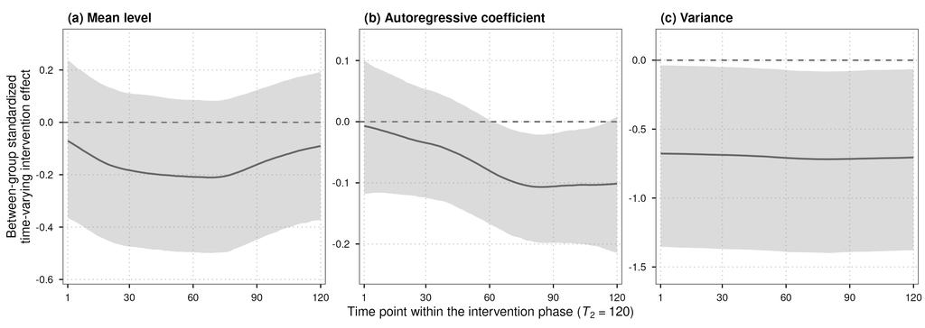

```r
# Between-group time-varying effects (intervention minus control).
plot_trajectories_1x3(
  read.csv(file.path("tables",
                     "between_group_time_effects.csv")),
  "Between-group standardized\ntime-varying intervention effect",
  file.path(FIG_DIR, "figure6.png"))
```

The integrated between-group effect on the mean is -0.16 (95% CrI [-0.44, 0.12]), and its time-varying trajectory (panel a) never excludes zero. For inertia the integrated contrast is -0.07 (95% CrI [-0.16, 0.01]), whose CrI includes zero, yet the time-varying trajectory (panel b) is credibly negative in the second half of the intervention. The clearest group difference emerges for variability, with an integrated effect of -0.70 (95% CrI [-1.38, -0.06]) and a trajectory (panel c) that is credibly negative across essentially the entire phase.